# Confirmatory: There is a power law of joint communicative effort and it reflects communicative work (version R2)

2025-08-08

This document contains all the plots and statistical testing for the confirmatory study. Every header with a confirmatory label is considered the prime analyses to be replicated in the large confirmatory dataset. The other analyses labeled exploratory we will perform but should be treated as such.

## setup dir & read processed datasets

```r
curfolder <- getwd()
outputfolder <- paste0(curfolder, "/output_large/")

# loglog/linear LMs intercepts/slopes
final_mat<-read.csv(paste0(outputfolder,"mat_lm_prepost_centered_shift_one.csv"))
final_mat_linear <- read.csv(paste0(outputfolder,"mat_lm_prepost_centered_linear.csv"))

# raw sum(energy) per pair
energy <- read.csv(paste0(outputfolder,"energy_n.csv"))

# raw energy per participant
mat_diff <- read.csv(paste0(outputfolder,"mat_diff.csv"))

# pre/post/visual centrality, average all the rest Fribbles for each Fribble (result in 1 x 16)
centrality_all <- read.csv(paste0(outputfolder,"centrality_all.csv"))

# centrality in long format: post and pre distances
rdm_pair_long <- read.csv(paste0(outputfolder,"rdm_pair_long.csv"))

# visual similarity 16 x 16 Fribbles
vis_sim <- read.csv(paste0(outputfolder,"Ssim_RDM.csv"),header = F)
vis_sim <- vis_sim[1:16,1:16]
vis_sim[row(vis_sim)==col(vis_sim)] <- NA

# post/pre centrality
rdm_mat <- read.csv(paste0(outputfolder,"rdm_mat_post.csv"))
rdm_mat_pre <- read.csv(paste0(outputfolder,"rdm_mat_pre.csv"))

# features
features <- read.csv(paste0(curfolder,"/features_exploratory/features_processed.csv"))

# make a color palette for 16 fribbles
my_custom_palette <- c("#1f78b4", "#33a02c", "#e31a1c", "#ff7f00", "#6a3d9a", "#a6cee3", "#b2df8a", "#fb9a99", "#fdbf6f", "#cab2d6", "#ffff99", "#b15928", "#8dd3c7", "#fb8072", "#80b1d3", "#bebada")

my2_custom_palette <- c("#1f78b4", "#33a02c", "#e31a1c", "#ff7f00", "#6a3d9a", "#a6cee3", "#b2df8a", "#fb9a99", "#fdbf6f", "#cab2d6", "#ffff99", "#b15928", "#8dd3c7", "#fb8072", "#80b1d3", "#bebada", "#377eb8", "#4daf4a", "#e41a1c", "#ff7f00", "#984ea3", "#a6cee3", "#b8e186", "#fc8d62", "#fdbf6f", "#8c510a", "#ffff99", "#d73027", "#4575b4", "#fc9272", "#91bfdb", "#d0d1e6", "#54278f", "#313695", "#fee08b", "#bd0026", "#66c2a5", "#393b79", "#637939", "#af8d12", "#d6616b", "#843c39", "#7b4173")

my3_custom_palette  <- c("#1a9641", "#a6d96a", "#fdae61", "#fee08b", "#e0f3f8", "#4575b4", "#313695", "#66c2a5", "#d73027", "#313695", "#74add1", "#4575b4", "#313695", "#e0f3f8", "#31a354", "#225ea8", "#253494", "#a6bddb", "#2171b5", "#238b45", "#fd8d3c")
```

```r
curfolder <- dirname(getwd())
outputfolder <- paste0(curfolder, "/preregistration/processed/")

# loglog/linear LMs intercepts/slopes
expl_final_mat<-read.csv(paste0(outputfolder,"mat_lm_prepost_centered_shift_one.csv"))
expl_final_mat_linear <- read.csv(paste0(outputfolder,"mat_lm_prepost_centered_linear.csv"))

# raw sum(energy) per pair
expl_energy <- read.csv(paste0(outputfolder,"energy.csv"))

# raw energy per participant
expl_mat_diff <- read.csv(paste0(outputfolder,"mat_diff.csv"))

# pre/post/visual centrality, average all the rest Fribbles for each Fribble (result in 1 x 16)
expl_centrality_all <- read.csv(paste0(outputfolder,"centrality_all.csv"))

# centrality in long format: post and pre distances
expl_rdm_pair_long <- read.csv(paste0(outputfolder,"rdm_pair_long.csv"))

# visual similarity 16 x 16 Fribbles
expl_vis_sim <- read.csv(paste0(outputfolder,"Ssim_RDM.csv"),header = F)
expl_vis_sim <- vis_sim[1:16,1:16]
expl_vis_sim[row(vis_sim)==col(vis_sim)] <- NA

# post/pre centrality
expl_rdm_mat <- read.csv(paste0(outputfolder,"rdm_mat_post.csv"))
expl_rdm_mat_pre <- read.csv(paste0(outputfolder,"rdm_mat_pre.csv"))
```

# Notes

- avg_dist: change, avg(A(pre,post), B(pre,post))
- prepost_convergence: convergence, pre(A,B)-post(A,B)

## linear vs. loglog plot: for average efforts and 4 measures seperately

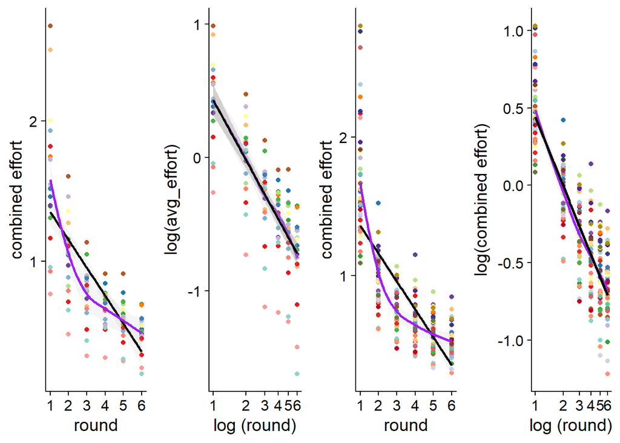

```r
####################Exploratory
tmp <- expl_mat_diff
tmp$trial <- NULL

tmp<- tmp %>% group_by(round,pair) %>% summarise(avg_env=mean(peaks1+peaks2),avg_ges=mean(gesture1+gesture2),avg_trans=mean(transitions),avg_f0range=mean(range1+range2))


tmp[,c(3:6)] <- scale(tmp[,c(3:6)], center = FALSE) ### center = false DEVIATION from pre-reg

tmp$avg_effort <- rowMeans(tmp[,c(3:6)])

expl_p1 <- ggplot(tmp,aes(x=round,y=avg_effort)) + geom_point(aes(colour=as.factor(pair), group=as.factor(pair)))+ guides(colour="none")+geom_smooth(method='lm', color='black', alpha=0.1)+geom_smooth(method='loess', color='purple', alpha=0.1)+ylab("combined effort")+theme_cowplot()+ theme(legend.position = "none")+ scale_color_manual(values = my2_custom_palette)+scale_x_continuous(name="round", breaks=c(1:6))+
    theme(legend.justification = "left")


expl_p2 <- ggplot(tmp,aes(x=round,y=log(avg_effort))) + geom_point(aes(colour=as.factor(pair), group=as.factor(pair)))+geom_smooth(method='loess', color='purple', alpha=0.1)+geom_smooth(method='lm', color='black')+scale_colour_discrete(name="Pair")+theme_cowplot()+ theme(legend.position = "none")+ scale_color_manual(values = my2_custom_palette)+scale_x_continuous(trans='log')+scale_x_continuous(trans='log', name="log (round)", breaks=c(1:6))


A <- ggarrange(expl_p1,expl_p2)


# Confirmatory
tmp <- mat_diff
tmp$trial <- NULL

tmp<- tmp %>% group_by(round,pair) %>% summarise(avg_env=mean(peaks1+peaks2),avg_ges=mean(gesture1+gesture2),avg_trans=mean(transitions),avg_f0range=mean(range1+range2))


tmp[,c(3:6)] <- scale(tmp[,c(3:6)], center = FALSE) ### center = false DEVIATION from pre-reg

tmp$avg_effort <- rowMeans(tmp[,c(3:6)])

p1 <- ggplot(tmp,aes(x=round,y=avg_effort)) + geom_point(aes(colour=as.factor(pair), group=as.factor(pair)))+ guides(colour="none")+geom_smooth(method='lm', color='black', alpha=0.1)+geom_smooth(method='loess', color='purple', alpha=0.1)+ylab("combined effort")+theme_cowplot()+ theme(legend.position = "none")+ scale_color_manual(values = my2_custom_palette)+scale_x_continuous(name="round", breaks=c(1:6))+
    theme(legend.justification = "left")


p2 <- ggplot(tmp,aes(x=round,y=log(avg_effort))) + geom_point(aes(colour=as.factor(pair), group=as.factor(pair)))+geom_smooth(method='loess', color='purple', alpha=0.1)+geom_smooth(method='lm', color='black', alpha=0.1)+ylab("log(combined effort)")+scale_colour_discrete(name="Pair")+theme_cowplot()+ theme(legend.position = "none")+ scale_color_manual(values = my2_custom_palette)+scale_x_continuous(trans='log')+scale_x_continuous(trans='log', name="log (round)", breaks=c(1:6))+
    theme(legend.justification = "left")


B <- ggarrange(p1,p2)

plot_grid(A, B, align = "hv")
```

# External Dataset Hawkins et al. (2023) and other datasets

```r
# external dataset
fnam <- paste0(curfolder,'/confirmatory/external_datasets/HawkinsFranketal2023_dataset/tangramsSequential.csv')
extdat <- read.csv(fnam)

extdatav <- extdat  %>% group_by(repetitionNum,gameid) %>% summarise(avg_words=mean(numRawWords))
```

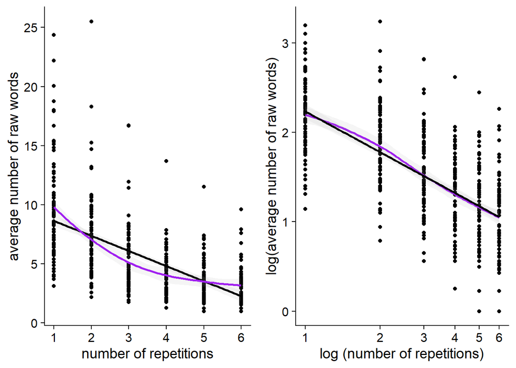

```r
p1 <- ggplot(extdatav,aes(x=repetitionNum,y=avg_words)) + geom_point(aes(group=as.factor(gameid)))+ guides(colour="none")+geom_smooth(method='lm', color='black', alpha=0.1)+geom_smooth(method='loess', color='purple', alpha=0.1)+ylab("average number of raw words")+theme_cowplot()+ theme(legend.position = "none")+scale_x_continuous(name="number of repetitions", breaks=c(1:6))+
    theme(legend.justification = "left")

p2 <- ggplot(extdatav,aes(x=repetitionNum,y=log(avg_words))) + geom_point(aes(group=as.factor(gameid)))+geom_smooth(method='loess', color='purple', alpha=0.1)+geom_smooth(method='lm', color='black', alpha=0.1)+ylab("log(average number of raw words)")+scale_colour_discrete(name="Pair")+theme_cowplot()+ theme(legend.position = "none")+scale_x_continuous(trans='log')+scale_x_continuous(trans='log', name="log (number of repetitions)", breaks=c(1:6))+
    theme(legend.justification = "left")
mplot <- grid.arrange(p1, p2 ,nrow= 1)
```

```r
#test R squared for mixed regression model
modelunt <- lmer(avg_words~repetitionNum+(1|gameid),data=extdatav)
summary(modelunt)
```

```
## Linear mixed model fit by REML. t-tests use Satterthwaite's method [
## lmerModLmerTest]
## Formula: avg_words ~ repetitionNum + (1 | gameid)
##    Data: extdatav
##
## REML criterion at convergence: 2356.8
##
## Scaled residuals:
##     Min      1Q  Median      3Q     Max
## -2.3401 -0.6169 -0.1276  0.4426  5.7252
##
## Random effects:
##  Groups   Name        Variance Std.Dev.
##  gameid   (Intercept) 3.808    1.952
##  Residual             4.961    2.227
## Number of obs: 498, groups:  gameid, 83
##
## Fixed effects:
##                Estimate Std. Error        df t value Pr(>|t|)
## (Intercept)     9.92687    0.31254 225.77815   31.76   <2e-16 ***
## repetitionNum  -1.27631    0.05844 414.00000  -21.84   <2e-16 ***
## ---
## Signif. codes:  0 '***' 0.001 '**' 0.01 '*' 0.05 '.' 0.1 ' ' 1
##
## Correlation of Fixed Effects:
##             (Intr)
## repetitinNm -0.654
```

```r
extdatav$avg_wordsl <- log(extdatav$avg_words)
extdatav$repetitionNuml <- log(extdatav$repetitionNum)
#test R squared for mixed regression model
modellog <- lmer(avg_wordsl~repetitionNuml+(1|gameid),data=extdatav)
summary(modellog)
```

```
## Linear mixed model fit by REML. t-tests use Satterthwaite's method [
## lmerModLmerTest]
## Formula: avg_wordsl ~ repetitionNuml + (1 | gameid)
##    Data: extdatav
##
## REML criterion at convergence: 369.3
##
## Scaled residuals:
##     Min      1Q  Median      3Q     Max
## -2.9455 -0.6120  0.0407  0.5494  3.2022
##
## Random effects:
##  Groups   Name        Variance Std.Dev.
##  gameid   (Intercept) 0.11997  0.3464
##  Residual             0.08275  0.2877
## Number of obs: 498, groups:  gameid, 83
##
## Fixed effects:
##                 Estimate Std. Error        df t value Pr(>|t|)
## (Intercept)      2.23437    0.04645 143.71159   48.10   <2e-16 ***
## repetitionNuml  -0.65874    0.02131 414.00000  -30.91   <2e-16 ***
## ---
## Signif. codes:  0 '***' 0.001 '**' 0.01 '*' 0.05 '.' 0.1 ' ' 1
##
## Correlation of Fixed Effects:
##             (Intr)
## repetitnNml -0.503
```

```r
#test R squared logarithmic for mixed regression model
modelloga <- lmer(avg_words~repetitionNuml+(1|gameid),data=extdatav)

#Determine R2:
r.squaredGLMM(modelunt)
```

```
##            R2m       R2c
## [1,] 0.3518722 0.6333612
```

```r
#Determine R2:
r.squaredGLMM(modellog)
```

```
##            R2m      R2c
## [1,] 0.4397276 0.771295
```

```r
#Determine R2:
print('logarithmic R2 for Hawkins')
```

```
## [1] "logarithmic R2 for Hawkins"
```

```r
r.squaredGLMM(modelloga)
```

```
##           R2m       R2c
## [1,] 0.394465 0.6844797
```

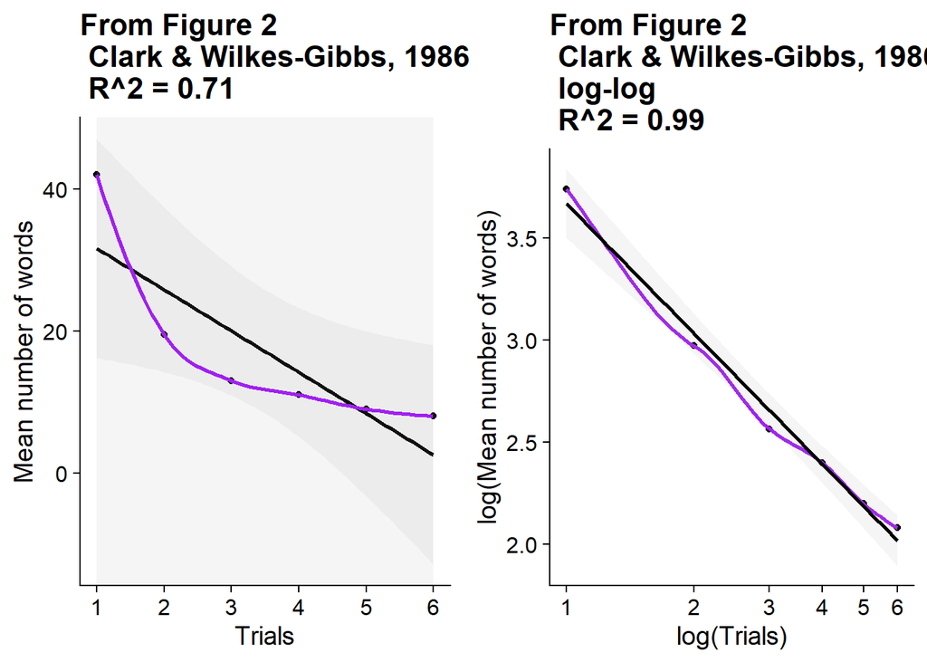

```r
# Lets add manually derived data
study1 <- "From Figure 2 \n Clark & Wilkes-Gibbs, 1986"
xlabel1 <- 'Trials'
ylabel1 <- 'Mean number of words'
x1 <- c(1:6)
y1 <- c(42, 19.5, 13, 11, 9, 8) #estimated from the figure
dd1 <- cbind.data.frame(x1, y1)

# Compute R-squared
model <- lm(y1 ~ x1, data  = dd1)
r_squared1 <- summary(model)$r.squared
r_squared1 <- round(r_squared1, 2)

# Compute R-squared
model <- lm(log(y1) ~ log(x1), data  = dd1)
r_squared1_log <- summary(model)$r.squared
r_squared1_log <- round(r_squared1_log, 2)

p1 <- ggplot(dd1,aes(x=x1,y=y1)) + geom_point()+ guides(colour="none")+geom_smooth(method='lm', color='black', alpha=0.1)+geom_smooth(method='loess', color='purple', alpha=0.1)+ylab(ylabel1)+theme_cowplot()+ theme(legend.position = "none")+scale_x_continuous(name=xlabel1, breaks=c(1:6))+
    theme(legend.justification = "left")+ggtitle(paste0(study1, '\n R^2 = ', r_squared1))

p2 <- ggplot(dd1,aes(x=x1,y=log(y1))) + geom_point()+geom_smooth(method='loess', color='purple', alpha=0.1)+geom_smooth(method='lm', color='black', alpha=0.1)+ylab(paste0('log(', ylabel1, ')'))+scale_colour_discrete(name="Pair")+theme_cowplot()+ theme(legend.position = "none")+scale_x_continuous(trans='log')+scale_x_continuous(trans='log', name=paste0("log(", xlabel1, ')'), breaks=c(1:6))+
    theme(legend.justification = "left")+ggtitle(paste0(study1, '\n log-log', '\n R^2 = ', r_squared1_log))
handplot1 <- grid.arrange(p1, p2 ,nrow= 1)
```

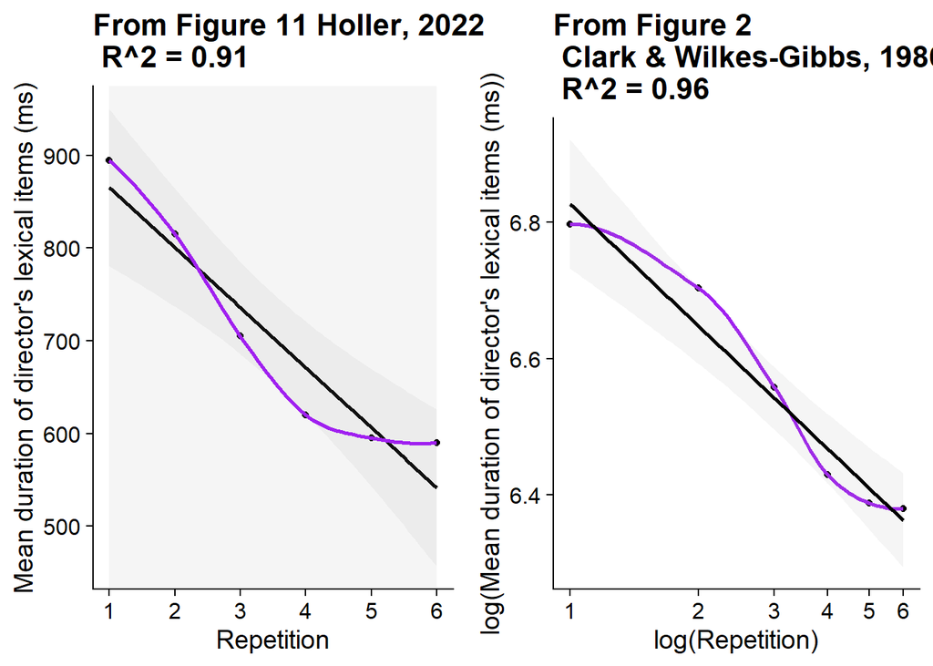

```r
study2 <- 'From Figure 11 Holler, 2022'
xlabel2 <- 'Repetition'
ylabel2 <- c("Mean duration of director's lexical items (ms)")
x2 <- c(0:5)
y2 <- c(895, 815, 705, 620, 595, 590) #estimated from the figure
dd2 <- cbind.data.frame(x2, y2)

# Compute R-squared
model <- lm(y2 ~ x2, data  = dd2)
r_squared2 <- summary(model)$r.squared
r_squared2 <- round(r_squared2, 2)

# Compute R-squared
model <- lm(log(y2) ~ log(x2+1), data  = dd2) # the rounds count from 0, but this gives issues with log, so we count from 1
r_squared2_log <- summary(model)$r.squared
r_squared2_log <- round(r_squared2_log, 2)


p1 <- ggplot(dd2,aes(x=x2+1,y=y2)) + geom_point()+ guides(colour="none")+geom_smooth(method='lm', color='black', alpha=0.1)+geom_smooth(method='loess', color='purple', alpha=0.1)+ylab(ylabel2)+theme_cowplot()+ theme(legend.position = "none")+scale_x_continuous(name=xlabel2, breaks=c(1:6))+
    theme(legend.justification = "left")+ggtitle(study2)+ggtitle(paste0(study2, '\n R^2 = ', r_squared2))

p2 <- ggplot(dd2,aes(x=x2+1,y=log(y2))) + geom_point()+geom_smooth(method='loess', color='purple', alpha=0.1)+geom_smooth(method='lm', color='black', alpha=0.1)+ylab(paste0('log(', ylabel2, ')'))+scale_colour_discrete(name="Pair")+theme_cowplot()+ theme(legend.position = "none")+scale_x_continuous(trans='log')+scale_x_continuous(trans='log', name=paste0("log(", xlabel2, ')'), breaks=c(1:6))+
    theme(legend.justification = "left")+ggtitle(paste0(study2, '\n log-log'))+ggtitle(paste0(study1, '\n R^2 = ', r_squared2_log))
handplot2 <- grid.arrange(p1, p2 ,nrow= 1)
```

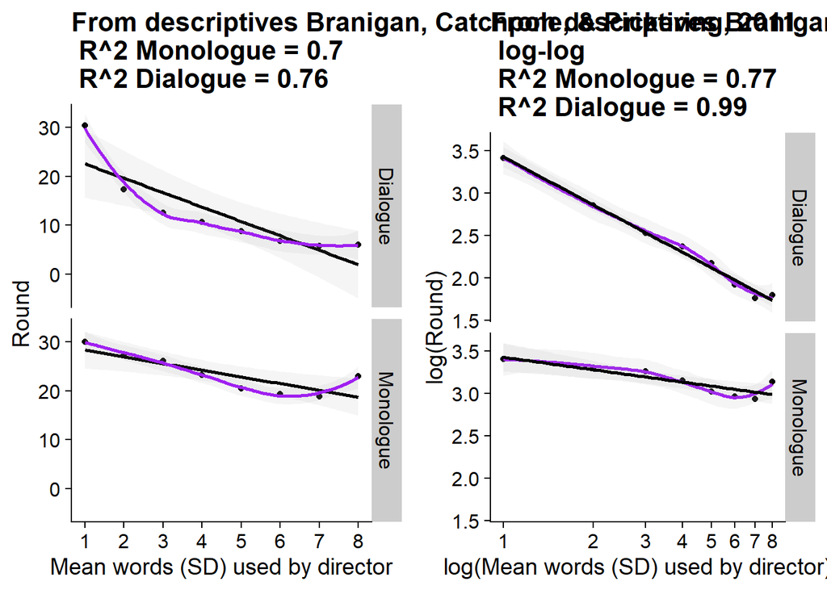

```r
study3 <- c('From descriptives Branigan, Catchpole, & Pickering, 2011')
fac3 <- c(rep('Monologue', times=8), rep('Dialogue', times=8) )
xlabel3 <- 'Mean words (SD) used by director'
ylabel3 <- 'Round'
x3   <- c(1:8)
y3 <- c(30.1, 27.3, 26.1, 23.3, 20.5, 19.4, 18.8, 23.0,
        30.4, 17.3, 12.5, 10.7, 8.8, 6.8, 5.8, 6.0) #from descriptives
dd3 <- cbind.data.frame(x3, y3, fac3)

# Compute R-squared
dd3$fac3 <- as.factor(dd3$fac3)
model <- lm(y3 ~ x3, data  = dd3[dd3$fac3=='Monologue',])
r_squared3_mono <- summary(model)$r.squared
r_squared3_mono <- round(r_squared3_mono, 2)

# Compute R-squared
model <- lm(log(y3) ~ log(x3+1), data  = dd3[dd3$fac3=='Monologue',]) # the rounds count from 0, but this gives issues with log, so we count from 1
r_squared3_log_mono <- summary(model)$r.squared
r_squared3_log_mono <- round(r_squared3_log_mono, 2)

# Compute R-squared
dd3$fac3 <- as.factor(dd3$fac3)
model <- lm(y3 ~ x3, data  = dd3[dd3$fac3=='Dialogue',])
r_squared3_dia <- summary(model)$r.squared
r_squared3_dia <- round(r_squared3_dia,2)

# Compute R-squared
model <- lm(log(y3) ~ log(x3+1), data  = dd3[dd3$fac3=='Dialogue',]) # the rounds count from 0, but this gives issues with log, so we count from 1
r_squared3_log_dia <- summary(model)$r.squared
r_squared3_log_dia  <- round(r_squared3_log_dia,2)


p1 <- ggplot(dd3,aes(x=x3,y=y3)) + geom_point()+ guides(colour="none")+geom_smooth(method='lm', color='black', alpha=0.1)+geom_smooth(method='loess', color='purple', alpha=0.1)+ylab(ylabel3)+theme_cowplot()+ theme(legend.position = "none")+scale_x_continuous(name=xlabel3, breaks=c(1:8))+
    theme(legend.justification = "left")+ggtitle(paste0(study3, '\n R^2 Monologue = ', r_squared3_mono, '\n R^2 Dialogue = ',  r_squared3_dia)) + facet_grid(fac3~.)

p2 <- ggplot(dd3,aes(x=x3,y=log(y3))) + geom_point()+geom_smooth(method='loess', color='purple', alpha=0.1)+geom_smooth(method='lm', color='black', alpha=0.1)+ylab(paste0('log(', ylabel3, ')'))+scale_colour_discrete(name="fac3")+theme_cowplot()+ theme(legend.position = "none")+scale_x_continuous(trans='log')+scale_x_continuous(trans='log', name=paste0("log(", xlabel3, ')'), breaks=c(1:8))+
    theme(legend.justification = "left")+ggtitle(paste0(study3, '\n log-log', '\n R^2 Monologue = ', r_squared3_log_mono, '\n R^2 Dialogue = ',  r_squared3_log_dia))+ facet_grid(fac3~.)
handplot3 <- grid.arrange(p1, p2 ,nrow= 1)
```

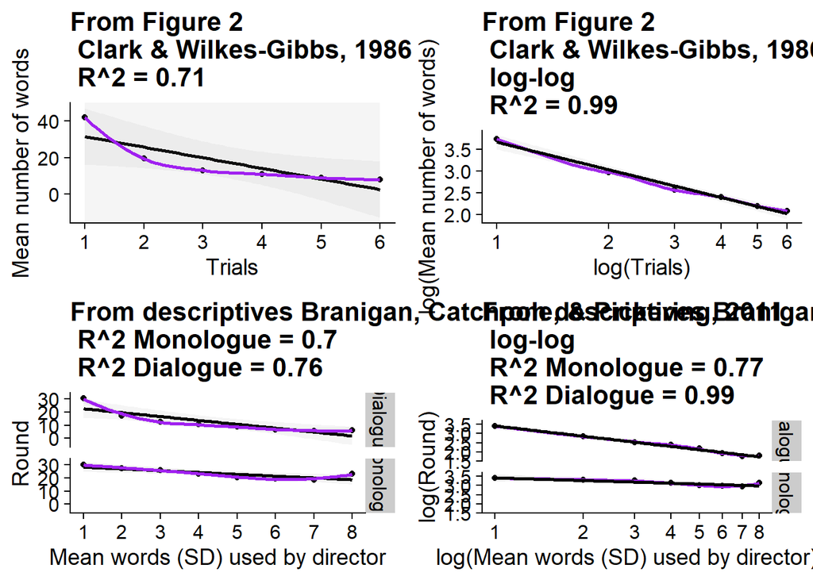

```r
handplots <- grid.arrange(handplot1, handplot3)
```

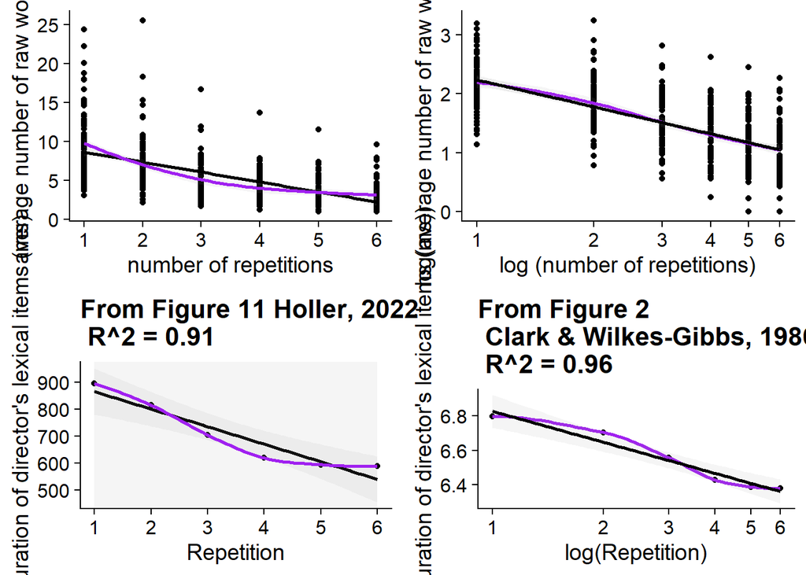

```r
hawkhand <- grid.arrange(mplot, handplot2)
```

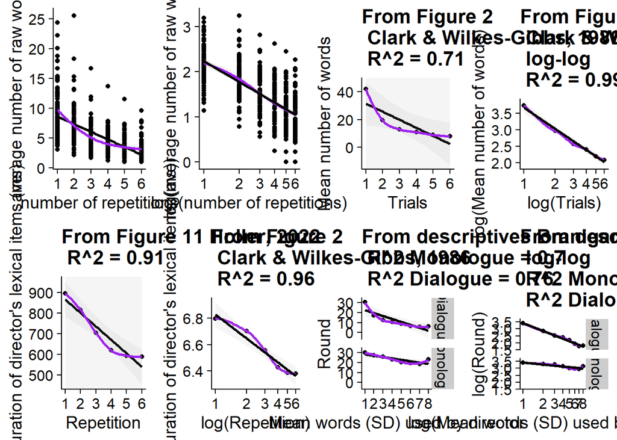

```r
grid.arrange(hawkhand, handplots, nrow= 1)
```

# Explained variance log-log versus untransformed

```r
# Exploratory
library(MuMIn)
tmp <- expl_mat_diff
tmp$File <- NULL

tmp<- tmp %>% group_by(round,pair) %>% summarise(avg_env=mean(peaks1+peaks2),avg_ges=mean(gesture1+gesture2),avg_trans=mean(transitions),avg_f0range=mean(range1+range2))


tmp[,c(3:6)] <- scale(tmp[,c(3:6)], center = FALSE) # DEVIATION pre-registration

tmp$avg_effort <- rowMeans(tmp[,c(3:6)])

#test R squared for mixed regression model
modelunt <- lmer(avg_effort~round+(1|pair),data=tmp)
summary(modelunt)
```

```
## Linear mixed model fit by REML. t-tests use Satterthwaite's method [
## lmerModLmerTest]
## Formula: avg_effort ~ round + (1 | pair)
##    Data: tmp
##
## REML criterion at convergence: 36.4
##
## Scaled residuals:
##     Min      1Q  Median      3Q     Max
## -1.7014 -0.5882 -0.1229  0.4194  4.2069
##
## Random effects:
##  Groups   Name        Variance Std.Dev.
##  pair     (Intercept) 0.03044  0.1745
##  Residual             0.05875  0.2424
## Number of obs: 114, groups:  pair, 19
##
## Fixed effects:
##             Estimate Std. Error       df t value Pr(>|t|)
## (Intercept)  1.55292    0.06544 61.33420   23.73   <2e-16 ***
## round       -0.19918    0.01329 94.00000  -14.98   <2e-16 ***
## ---
## Signif. codes:  0 '***' 0.001 '**' 0.01 '*' 0.05 '.' 0.1 ' ' 1
##
## Correlation of Fixed Effects:
##       (Intr)
## round -0.711
```

```r
tmp$avg_effortl <- log(tmp$avg_effort)
tmp$roundl <- log(tmp$round)
#test R squared for mixed regression model
modellog <- lmer(avg_effortl~roundl+(1|pair),data=tmp)
summary(modellog)
```

```
## Linear mixed model fit by REML. t-tests use Satterthwaite's method [
## lmerModLmerTest]
## Formula: avg_effortl ~ roundl + (1 | pair)
##    Data: tmp
##
## REML criterion at convergence: -57
##
## Scaled residuals:
##      Min       1Q   Median       3Q      Max
## -2.89605 -0.47420  0.03385  0.42077  2.66030
##
## Random effects:
##  Groups   Name        Variance Std.Dev.
##  pair     (Intercept) 0.06613  0.2572
##  Residual             0.02004  0.1416
## Number of obs: 114, groups:  pair, 19
##
## Fixed effects:
##             Estimate Std. Error       df t value Pr(>|t|)
## (Intercept)  0.42706    0.06507 24.02163   6.563 8.64e-07 ***
## roundl      -0.63970    0.02192 94.00000 -29.187  < 2e-16 ***
## ---
## Signif. codes:  0 '***' 0.001 '**' 0.01 '*' 0.05 '.' 0.1 ' ' 1
##
## Correlation of Fixed Effects:
##        (Intr)
## roundl -0.369
```

```r
#Determine R2:
r.squaredGLMM(modelunt)
```

```
##            R2m       R2c
## [1,] 0.5668746 0.7147007
```

```r
#Determine R2:
r.squaredGLMM(modellog)
```

```
##            R2m       R2c
## [1,] 0.6367832 0.9155329
```

```r
######## COnfirmatory

library(MuMIn)
tmp <- mat_diff
tmp$File <- NULL

tmp<- tmp %>% group_by(round,pair) %>% summarise(avg_env=mean(peaks1+peaks2),avg_ges=mean(gesture1+gesture2),avg_trans=mean(transitions),avg_f0range=mean(range1+range2))


tmp[,c(3:6)] <- scale(tmp[,c(3:6)], center = FALSE) # DEVIATION pre-registration

tmp$avg_effort <- rowMeans(tmp[,c(3:6)])

#test R squared for mixed regression model
modelunt <- lmer(avg_effort~round+(1|pair),data=tmp)
summary(modelunt)
```

```
## Linear mixed model fit by REML. t-tests use Satterthwaite's method [
## lmerModLmerTest]
## Formula: avg_effort ~ round + (1 | pair)
##    Data: tmp
##
## REML criterion at convergence: 105.1
##
## Scaled residuals:
##     Min      1Q  Median      3Q     Max
## -1.5559 -0.6082 -0.2001  0.4752  4.6229
##
## Random effects:
##  Groups   Name        Variance Std.Dev.
##  pair     (Intercept) 0.009358 0.09674
##  Residual             0.077684 0.27872
## Number of obs: 252, groups:  pair, 42
##
## Fixed effects:
##              Estimate Std. Error        df t value Pr(>|t|)
## (Intercept)   1.56147    0.04273 223.73197   36.54   <2e-16 ***
## round        -0.20144    0.01028 209.00000  -19.59   <2e-16 ***
## ---
## Signif. codes:  0 '***' 0.001 '**' 0.01 '*' 0.05 '.' 0.1 ' ' 1
##
## Correlation of Fixed Effects:
##       (Intr)
## round -0.842
```

```r
tmp$avg_effortl <- log(tmp$avg_effort)
tmp$roundl <- log(tmp$round)
#test R squared for mixed regression model
modellog <- lmer(avg_effortl~roundl+(1|pair),data=tmp)
summary(modellog)
```

```
## Linear mixed model fit by REML. t-tests use Satterthwaite's method [
## lmerModLmerTest]
## Formula: avg_effortl ~ roundl + (1 | pair)
##    Data: tmp
##
## REML criterion at convergence: -142.7
##
## Scaled residuals:
##     Min      1Q  Median      3Q     Max
## -2.0669 -0.6171 -0.0447  0.4603  3.3493
##
## Random effects:
##  Groups   Name        Variance Std.Dev.
##  pair     (Intercept) 0.02908  0.1705
##  Residual             0.02223  0.1491
## Number of obs: 252, groups:  pair, 42
##
## Fixed effects:
##              Estimate Std. Error        df t value Pr(>|t|)
## (Intercept)   0.44124    0.03272  75.07710   13.49   <2e-16 ***
## roundl       -0.64398    0.01553 209.00000  -41.47   <2e-16 ***
## ---
## Signif. codes:  0 '***' 0.001 '**' 0.01 '*' 0.05 '.' 0.1 ' ' 1
##
## Correlation of Fixed Effects:
##        (Intr)
## roundl -0.520
```

```r
#test R squared for mixed regression model logarithmic
modelloga <- lmer(avg_effort~roundl+(1|pair),data=tmp)
#summary(modelloga)

#Determine R2:
r.squaredGLMM(modelunt)
```

```
##            R2m       R2c
## [1,] 0.5771934 0.6226508
```

```r
#Determine R2:
r.squaredGLMM(modellog)
```

```
##            R2m       R2c
## [1,] 0.7480642 0.8908429
```

```r
# Determine R2 logarithmic
print("testing a logarithmic relationship where y = log(x)")
```

```
## [1] "testing a logarithmic relationship where y = log(x)"
```

```r
r.squaredGLMM(modelloga)
```

```
##            R2m       R2c
## [1,] 0.7081027 0.7797554
```

## Plot untransformed and log log

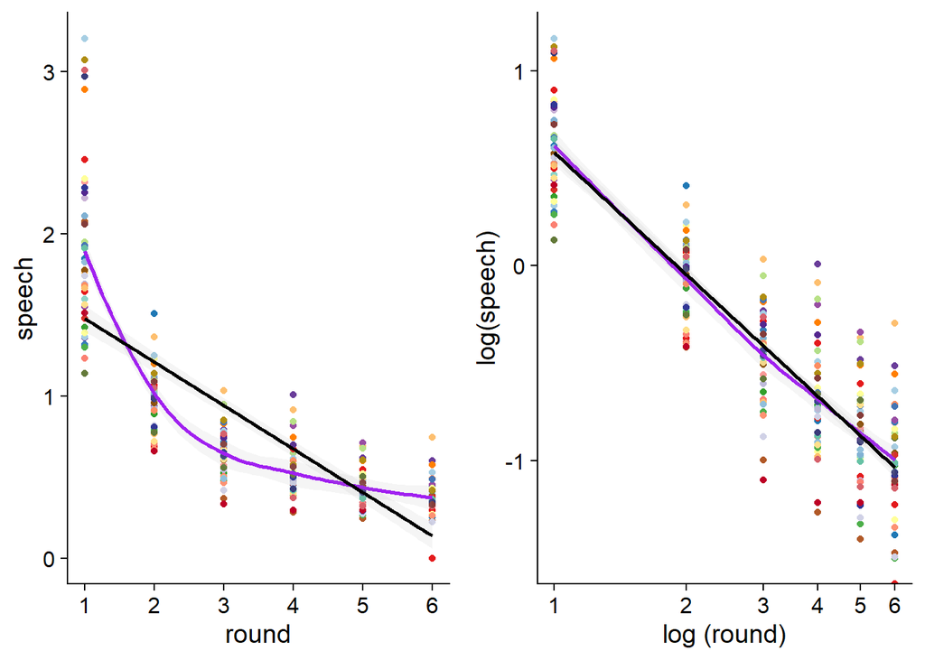

```r
tmp <- mat_diff
tmp$File <- NULL

tmp<- tmp %>% group_by(round,pair) %>% summarise(avg_env=mean(peaks1+peaks2),avg_ges=mean(gesture1+gesture2),avg_trans=mean(transitions),avg_f0range=mean(range1+range2))

tmp[,c(3:6)] <- scale(tmp[,c(3:6)], center = FALSE) # DEVIATION pre-registration
tmp$avg_effort <- rowMeans(tmp[,c(3:6)])

p1b <- ggplot(tmp,aes(x=round,y=log(avg_env))) + geom_point(aes(colour=as.factor(pair), group=as.factor(pair)))+geom_smooth(method='loess', color='purple', alpha=0.1)+geom_smooth(method='lm', color='black', alpha=0.1)+ylab("log(speech)")+scale_colour_discrete(name="Pair")+theme_cowplot()+ theme(legend.position = "none")+ scale_color_manual(values = my2_custom_palette)+scale_x_continuous(trans='log', name="log (round)", breaks=c(1:6))+
    theme(legend.justification = "left")

p1a <- ggplot(tmp,aes(x=round,y=avg_env)) + geom_point(aes(colour=as.factor(pair), group=as.factor(pair)))+geom_smooth(method='loess', color='purple', alpha=0.1)+geom_smooth(method='lm', color='black', alpha=0.1)+ylab("speech")+scale_colour_discrete(name="Pair")+theme_cowplot()+ theme(legend.position = "none")+ scale_color_manual(values = my2_custom_palette)+ scale_x_continuous(breaks=c(1:6))+
    theme(legend.justification = "left")

p1 <- grid.arrange(p1a, p1b, nrow= 1)
```

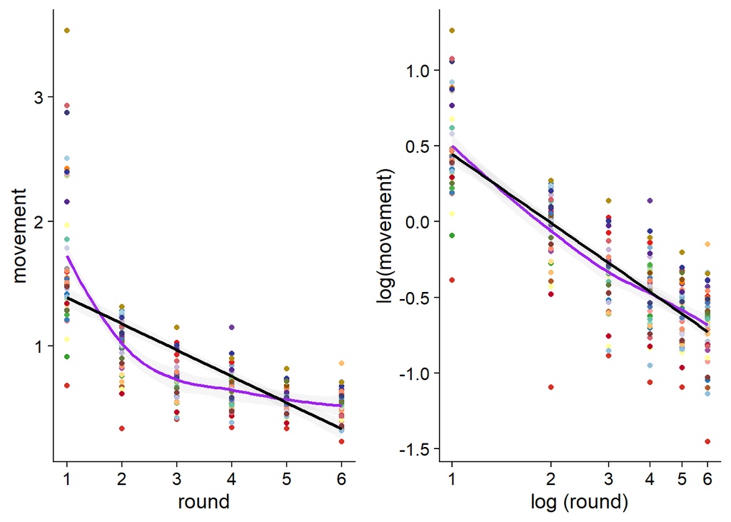

```r
p2b <- ggplot(tmp,aes(x=round,y=log(avg_ges))) + geom_point(aes(colour=as.factor(pair), group=as.factor(pair)))+geom_smooth(method='loess', color='purple', alpha=0.1)+geom_smooth(method='lm', color='black', alpha=0.1)+ylab("log(movement)")+scale_colour_discrete(name="Pair")+theme_cowplot()+ theme(legend.position = "none")+ scale_color_manual(values = my2_custom_palette)+scale_x_continuous(trans='log', name="log (round)", breaks=c(1:6))+
    theme(legend.justification = "left")

p2a <- ggplot(tmp,aes(x=round,y=avg_ges)) + geom_point(aes(colour=as.factor(pair), group=as.factor(pair)))+geom_smooth(method='loess', color='purple', alpha=0.1)+geom_smooth(method='lm', color='black', alpha=0.1)+ylab("movement")+scale_colour_discrete(name="Pair")+theme_cowplot()+ theme(legend.position = "none")+ scale_color_manual(values = my2_custom_palette)+ scale_x_continuous(breaks=c(1:6))+
    theme(legend.justification = "left")

p2 <- grid.arrange(p2a, p2b, nrow= 1)
```

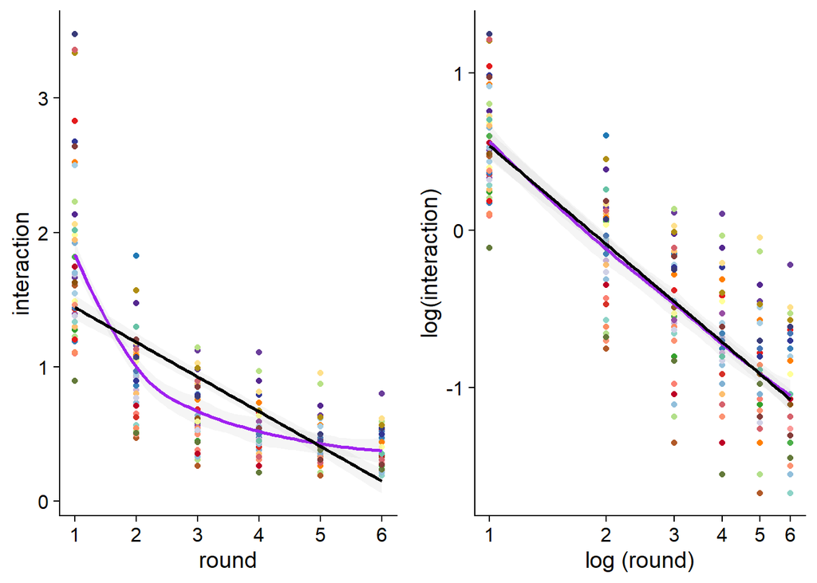

```r
p3b <- ggplot(tmp,aes(x=round,y=log(avg_trans))) + geom_point(aes(colour=as.factor(pair), group=as.factor(pair)))+geom_smooth(method='loess', color='purple', alpha=0.1)+geom_smooth(method='lm', color='black', alpha=0.1)+ylab("log(interaction)")+scale_colour_discrete(name="Pair")+theme_cowplot()+ theme(legend.position = "none")+ scale_color_manual(values = my2_custom_palette)+scale_x_continuous(trans='log', name="log (round)", breaks=c(1:6))+
    theme(legend.justification = "left")

p3a <- ggplot(tmp,aes(x=round,y=avg_trans)) + geom_point(aes(colour=as.factor(pair), group=as.factor(pair)))+geom_smooth(method='loess', color='purple', alpha=0.1)+geom_smooth(method='lm', color='black', alpha=0.1)+ylab("interaction")+scale_colour_discrete(name="Pair")+theme_cowplot()+ theme(legend.position = "none")+ scale_color_manual(values = my2_custom_palette)+ scale_x_continuous(breaks=c(1:6))+
    theme(legend.justification = "left")

p3 <- grid.arrange(p3a, p3b, nrow= 1)
```

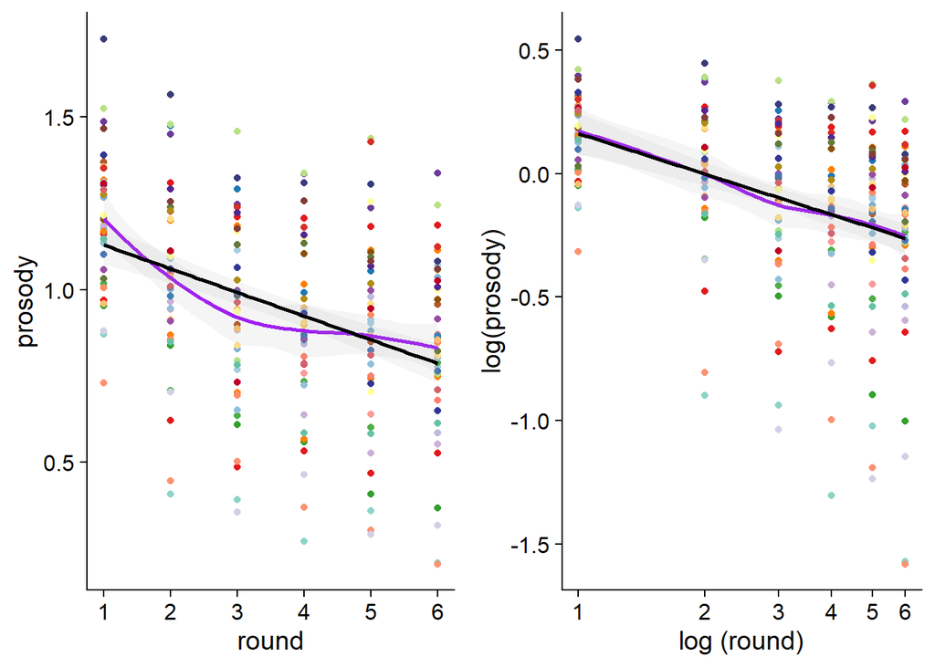

```r
p4b <- ggplot(tmp,aes(x=round,y=log(avg_f0range))) + geom_point(aes(colour=as.factor(pair), group=as.factor(pair)))+geom_smooth(method='loess', color='purple', alpha=0.1)+geom_smooth(method='lm', color='black', alpha=0.1)+ylab("log(prosody)")+scale_colour_discrete(name="Pair")+theme_cowplot()+ theme(legend.position = "none")+ scale_color_manual(values = my2_custom_palette)+scale_x_continuous(trans='log', name="log (round)", breaks=c(1:6))+
    theme(legend.justification = "left")

p4a <- ggplot(tmp,aes(x=round,y=avg_f0range)) + geom_point(aes(colour=as.factor(pair), group=as.factor(pair)))+geom_smooth(method='loess', color='purple', alpha=0.1)+geom_smooth(method='lm', color='black', alpha=0.1)+ylab("prosody")+scale_colour_discrete(name="Pair")+theme_cowplot()+ theme(legend.position = "none")+ scale_color_manual(values = my2_custom_palette)+ scale_x_continuous(breaks=c(1:6))+
    theme(legend.justification = "left")

p4 <- grid.arrange(p4a, p4b, nrow= 1)
```

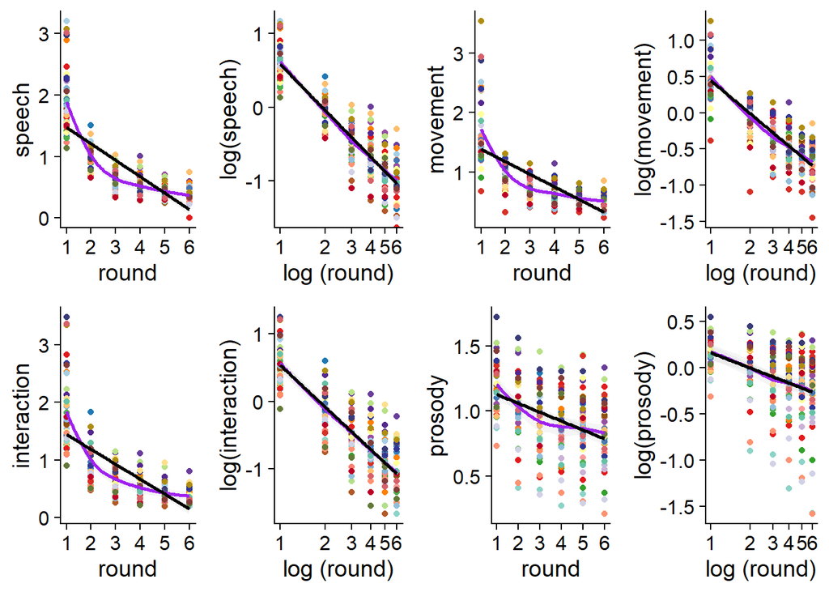

```r
grid.arrange(p1, p2, p3, p4)
```

## correlations: centrality of Fribbles (HYPOTHESIS 1)

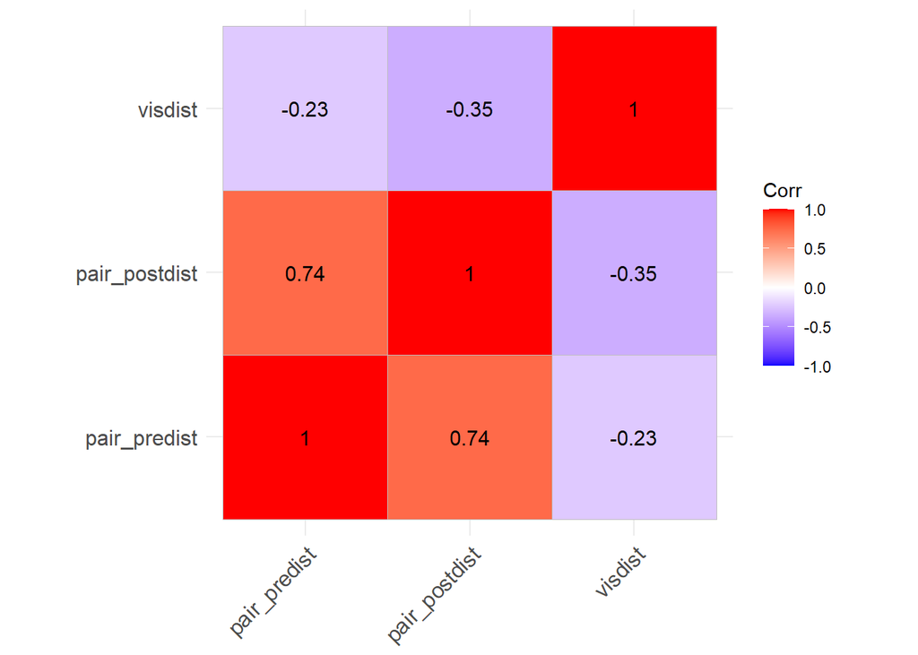

```r
ggcorrplot(cor(centrality_all[,2:4]),method="square",lab=T)
```

### Mantel test: conclusion the same as avg per Fribble (the fig above)

Pre naming vs visual dissimilarity (main confirmatory: Hypothesis 1)

```r
mantel.test(rdm_mat_pre,vis_sim) # set graph = T
```

```
## $z.stat
## [1] 4.638098
##
## $p
## [1] 0.355
##
## $alternative
## [1] "two.sided"
```

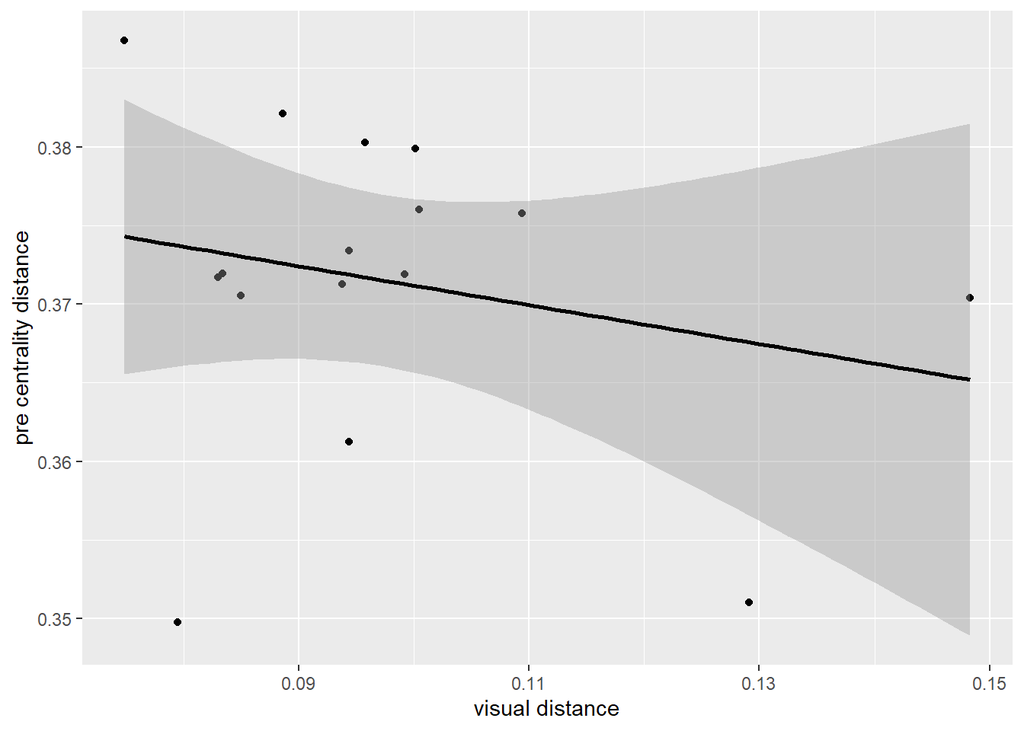

```r
ggplot(centrality_all,aes(x=visdist,y=pair_predist)) + geom_point()+geom_smooth(method='lm', color='black')+ylab("pre centrality distance")+xlab("visual distance")
```

Post naming vs visual dissimilarity (exploratory)

```r
mantel.test(rdm_mat,vis_sim)
```

```
## $z.stat
## [1] 5.502784
##
## $p
## [1] 0.201
##
## $alternative
## [1] "two.sided"
```

Pre naming vs post naming (exploratory)

```r
mantel.test(rdm_mat_pre,rdm_mat)
```

```
## $z.stat
## [1] 22.59246
##
## $p
## [1] 0.001
##
## $alternative
## [1] "two.sided"
```

Pre naming vs. post naming (exploratory)

```r
# double-check with vegan package - similar result
mantel.test(rdm_mat_pre,rdm_mat,na.rm = T) # 0.001 0.004 0.026
```

```
## $z.stat
## [1] 22.59246
##
## $p
## [1] 0.001
##
## $alternative
## [1] "two.sided"
```

## Prepare data for work analyses

```r
tmp_mat <- final_mat
tmp_mat[,c(3:14)] <- scale(tmp_mat[,c(3:14)])
tmp_mat$avg_intercepts <- rowMeans(tmp_mat[,c("trans_intercept","env_intercept","ges_intercept","f0_intercept")])
tmp_mat$avg_slopes <- rowMeans(tmp_mat[,c("trans_slope","env_slope","ges_slope","f0_slope")])
all <- left_join(tmp_mat[,c(1:16)],energy[,c(1,2,8)],by=c("pair","target"))
all<- left_join(all,rdm_pair_long[,c(1:3)],by=c("pair","target"="fribble"))

# rename variable so that they are not confusing
colnames(all)[colnames(all) == "prepost_change"] <- "prepost_convergence"


# do the same for exploratory dataset
expl_tmp_mat <- expl_final_mat
expl_tmp_mat[,c(3:14)] <- scale(expl_tmp_mat[,c(3:14)])
expl_tmp_mat$avg_intercepts <- rowMeans(expl_tmp_mat[,c("trans_intercept","env_intercept","ges_intercept","f0_intercept")])
expl_tmp_mat$avg_slopes <- rowMeans(expl_tmp_mat[,c("trans_slope","env_slope","ges_slope","f0_slope")])
expl_all <- left_join(expl_tmp_mat[,c(1:16)],expl_energy[,c(1,2,8)],by=c("pair","target"))
expl_all<- left_join(expl_all,expl_rdm_pair_long[,c(1:3)],by=c("pair","target"="fribble"))

# rename variable so that they are not confusing
colnames(expl_all)[colnames(expl_all) == "prepost_change"] <- "prepost_convergence"
```

## change ~ avg_slopes (confirmatory and exploratory)

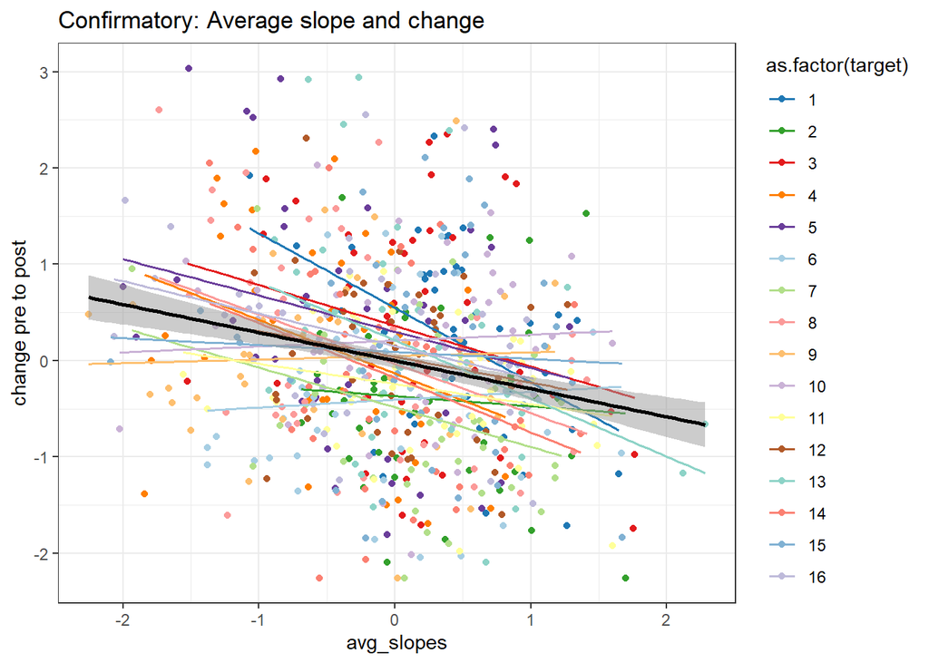

```r
p1 <- ggplot(all,aes(x=avg_slopes,y=avg_dist, color = as.factor(target))) + geom_point(aes(group=pair))+geom_smooth(method='lm', alpha = 0, size = 0.7)+geom_smooth(method='lm', alpha=0.5, color = 'black')+ylab("change pre to post")+ggtitle("Confirmatory: Average slope and change")+theme_bw()+ scale_color_manual(values = my_custom_palette)
p1
```

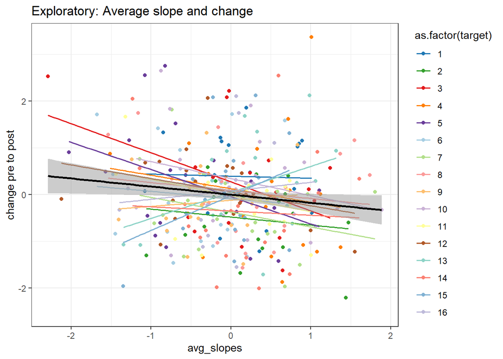

```r
p1_exploratory <- ggplot(expl_all,aes(x=avg_slopes,y=avg_dist, color = as.factor(target))) + geom_point(aes(group=pair))+geom_smooth(method='lm', alpha = 0, size = 0.7)+geom_smooth(method='lm', alpha=0.5, color = 'black')+ylab("change pre to post")+ggtitle("Exploratory: Average slope and change")+theme_bw()+ scale_color_manual(values = my_custom_palette)
p1_exploratory
```

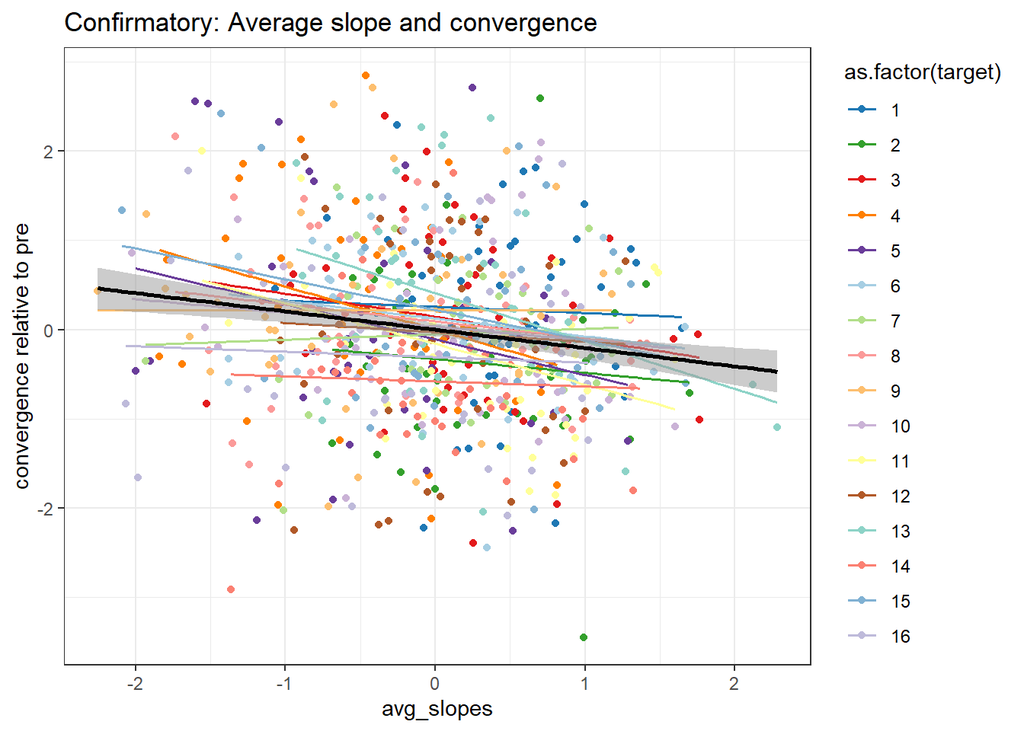

```r
# also show convergence
p1 <- ggplot(all,aes(x=avg_slopes,y=prepost_convergence, color = as.factor(target))) + geom_point(aes(group=pair))+geom_smooth(method='lm', alpha = 0, size = 0.7)+geom_smooth(method='lm', alpha=0.5, color = 'black')+ylab("convergence relative to pre")+ggtitle("Confirmatory: Average slope and convergence")+theme_bw()+ scale_color_manual(values = my_custom_palette)
p1
```

# slopes and change (Confirmatory hypothesis 2)

```r
model1 <- lmer(avg_dist~(1|target)+(1|pair)+avg_slopes,data=all)
summary(model1)
```

```
## Linear mixed model fit by REML. t-tests use Satterthwaite's method [
## lmerModLmerTest]
## Formula: avg_dist ~ (1 | target) + (1 | pair) + avg_slopes
##    Data: all
##
## REML criterion at convergence: 1829.5
##
## Scaled residuals:
##     Min      1Q  Median      3Q     Max
## -2.5837 -0.6712 -0.0051  0.6296  3.3197
##
## Random effects:
##  Groups   Name        Variance Std.Dev.
##  pair     (Intercept) 0.10510  0.3242
##  target   (Intercept) 0.05401  0.2324
##  Residual             0.79857  0.8936
## Number of obs: 672, groups:  pair, 42; target, 16
##
## Fixed effects:
##               Estimate Std. Error         df t value Pr(>|t|)
## (Intercept)  3.925e-17  8.406e-02  2.896e+01   0.000        1
## avg_slopes  -2.863e-01  5.294e-02  6.169e+02  -5.407 9.16e-08 ***
## ---
## Signif. codes:  0 '***' 0.001 '**' 0.01 '*' 0.05 '.' 0.1 ' ' 1
##
## Correlation of Fixed Effects:
##            (Intr)
## avg_slopes 0.000
```

```r
# Exploratory for convergence
model1 <- lmer(prepost_convergence~(1|target)+(1|pair)+avg_slopes,data=all)
summary(model1)
```

```
## Linear mixed model fit by REML. t-tests use Satterthwaite's method [
## lmerModLmerTest]
## Formula: prepost_convergence ~ (1 | target) + (1 | pair) + avg_slopes
##    Data: all
##
## REML criterion at convergence: 1823.9
##
## Scaled residuals:
##     Min      1Q  Median      3Q     Max
## -3.3719 -0.6214 -0.0192  0.6447  3.1754
##
## Random effects:
##  Groups   Name        Variance Std.Dev.
##  pair     (Intercept) 0.16013  0.4002
##  target   (Intercept) 0.04466  0.2113
##  Residual             0.77856  0.8824
## Number of obs: 672, groups:  pair, 42; target, 16
##
## Fixed effects:
##               Estimate Std. Error         df t value Pr(>|t|)
## (Intercept) -2.838e-18  8.811e-02  3.662e+01   0.000 1.000000
## avg_slopes  -2.004e-01  5.306e-02  6.414e+02  -3.776 0.000174 ***
## ---
## Signif. codes:  0 '***' 0.001 '**' 0.01 '*' 0.05 '.' 0.1 ' ' 1
##
## Correlation of Fixed Effects:
##            (Intr)
## avg_slopes 0.000
```

# slopes exploratory extension features

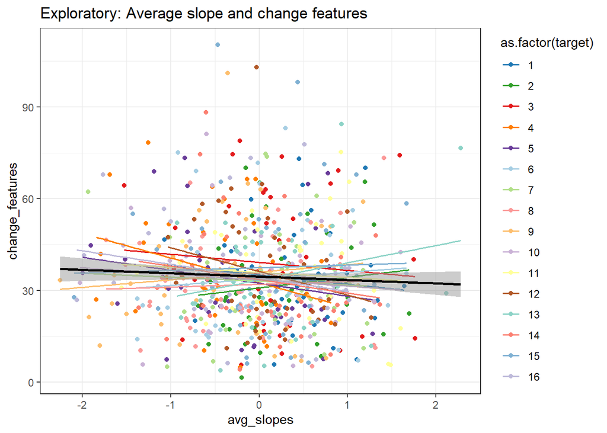

```r
# Notes
#+ avg_dist_exploratory: change, avg(A(pre,post), B(pre,post))
#+ prepost_convergence: convergence, pre(A,B)-post(A,B)
features <- read.csv(paste0(curfolder,"/confirmatory/features_exploratory/features_processed.csv"))

features$Session <- ifelse(features$Session==1, "pre", "post")

# Function to split number and remove leading zeros
split_number <- function(num) {
  left <- as.integer(substr(as.character(num), 1, nchar(num)/2))
  right <- as.integer(substr(as.character(num), (nchar(num)/2 + 1), nchar(num)))
  return(c(left, right))
}

# Apply the function to each number
result <- t(sapply(unique(all$pair), split_number))
# Create a data frame
result <- as.data.frame(result)
colnames(result) <- c("A", "B")
result$pair <- unique(all$pair)

# only keep the participants in this sample
features <- subset(features, features$ParticipantNr%in%c(result$A, result$B))

# now go through
all$change_features <- NA
all$change_convergence <- NA


# Pivot the data to have features as columns and scores as values
feats <- cbind.data.frame(features$Feature, features$Score)
colnames(feats) <- c("Feature", "Score")
pivot_features <- feats  %>%
  group_by(Feature) %>%
  mutate(row = row_number()) %>%
  pivot_wider(names_from = Feature, values_from = Score) %>%
  select(-row)

var_cov_matrix <- cov(pivot_features, use = "complete.obs")


# compute variance covariance matrix for all the features


for(i in unique(all$pair))
{
  for(f in unique(all$target))
  {
  # get the pp number
  A <- result$A[result$pair==i]
  B <- result$B[result$pair==i]
  # now select A's and B's features
  featuresApre <- features[features$ParticipantNr==A & features$Fribble==f & features$Session=="pre",]
  featuresApost <- features[features$ParticipantNr==A & features$Fribble==f & features$Session=="post",]
  featuresBpre <- features[features$ParticipantNr==B & features$Fribble==f & features$Session=="pre",]
  featuresBpost <- features[features$ParticipantNr==B & features$Fribble==f & features$Session=="post",]

  # change features avg(A(pre,post), B(pre,post))
  all$change_features[all$pair==i & all$target==f] <-  (mahalanobis(featuresApre$Score, featuresApost$Score, cov = var_cov_matrix)+mahalanobis(featuresBpre$Score, featuresBpost$Score, cov = var_cov_matrix))/2
  all$convergence_features[all$pair==i & all$target==f] <- mahalanobis(featuresApre$Score, featuresBpre$Score, cov = var_cov_matrix)-mahalanobis(featuresApost$Score, featuresBpost$Score, cov = var_cov_matrix)

  #all$change_features[all$pair==i & all$target==f] <- ((sqrt(sum((featuresApre$Score-featuresApost$Score)^2))) + sqrt(sum((featuresBpre$Score-featuresBpost$Score)^2)))/2
  # convergence pre(A,B)-post(A,B)
  #all$convergence_features[all$pair==i & all$target==f] <-  ((sqrt(sum((featuresApre$Score-featuresBpre$Scor)^2))) -sqrt(sum((featuresApost$Score-featuresBpost$Score)^2)))

  }
}

p1 <- ggplot(all,aes(x=avg_slopes,y=change_features, color = as.factor(target))) + geom_point(aes(group=pair))+geom_smooth(method='lm', alpha = 0, size = 0.7)+geom_smooth(method='lm', alpha=0.5, color = 'black')+ylab("change_features")+ggtitle("Exploratory: Average slope and change features")+theme_bw()+ scale_color_manual(values = my_custom_palette)
p1
```

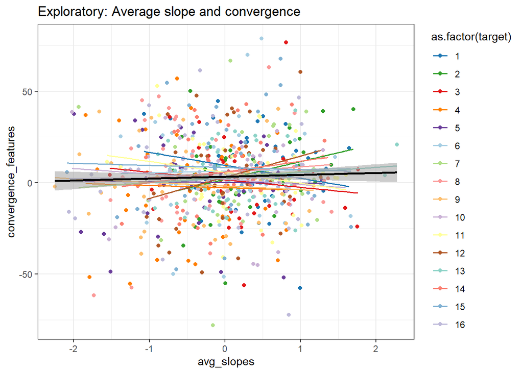

```r
p2 <- ggplot(all,aes(x=avg_slopes,y=convergence_features, color = as.factor(target))) + geom_point(aes(group=pair))+geom_smooth(method='lm', alpha = 0, size = 0.7)+geom_smooth(method='lm', alpha=0.5, color = 'black')+ylab("convergence_features")+ggtitle("Exploratory: Average slope and convergence")+theme_bw()+ scale_color_manual(values = my_custom_palette)
p2
```

```r
model1 <- lmer(change_features~(1|target)+(1|pair)+avg_slopes,data=all)
summary(model1)
```

```
## Linear mixed model fit by REML. t-tests use Satterthwaite's method [
## lmerModLmerTest]
## Formula: change_features ~ (1 | target) + (1 | pair) + avg_slopes
##    Data: all
##
## REML criterion at convergence: 5333.6
##
## Scaled residuals:
##     Min      1Q  Median      3Q     Max
## -2.7354 -0.6278 -0.0786  0.5208  4.0470
##
## Random effects:
##  Groups   Name        Variance Std.Dev.
##  pair     (Intercept) 171.1219 13.0814
##  target   (Intercept)   0.8157  0.9032
##  Residual             136.0241 11.6629
## Number of obs: 672, groups:  pair, 42; target, 16
##
## Fixed effects:
##             Estimate Std. Error       df t value Pr(>|t|)
## (Intercept)  34.5676     2.0803  41.5290  16.617  < 2e-16 ***
## avg_slopes   -2.1033     0.6995 444.7073  -3.007  0.00279 **
## ---
## Signif. codes:  0 '***' 0.001 '**' 0.01 '*' 0.05 '.' 0.1 ' ' 1
##
## Correlation of Fixed Effects:
##            (Intr)
## avg_slopes 0.000
```

```r
model2 <- lmer(convergence_features~(1|target)+(1|pair)+avg_slopes,data=all)
```

```
## boundary (singular) fit: see help('isSingular')
```

```r
summary(model2)
```

```
## Linear mixed model fit by REML. t-tests use Satterthwaite's method [
## lmerModLmerTest]
## Formula: convergence_features ~ (1 | target) + (1 | pair) + avg_slopes
##    Data: all
##
## REML criterion at convergence: 5987.1
##
## Scaled residuals:
##     Min      1Q  Median      3Q     Max
## -4.5518 -0.5392 -0.0333  0.5957  3.4645
##
## Random effects:
##  Groups   Name        Variance Std.Dev.
##  pair     (Intercept) 101.9    10.09
##  target   (Intercept)   0.0     0.00
##  Residual             395.4    19.88
## Number of obs: 672, groups:  pair, 42; target, 16
##
## Fixed effects:
##             Estimate Std. Error       df t value Pr(>|t|)
## (Intercept)   3.3126     1.7363  40.9903   1.908   0.0634 .
## avg_slopes    0.8495     1.1424 668.8680   0.744   0.4574
## ---
## Signif. codes:  0 '***' 0.001 '**' 0.01 '*' 0.05 '.' 0.1 ' ' 1
##
## Correlation of Fixed Effects:
##            (Intr)
## avg_slopes 0.000
## optimizer (nloptwrap) convergence code: 0 (OK)
## boundary (singular) fit: see help('isSingular')
```

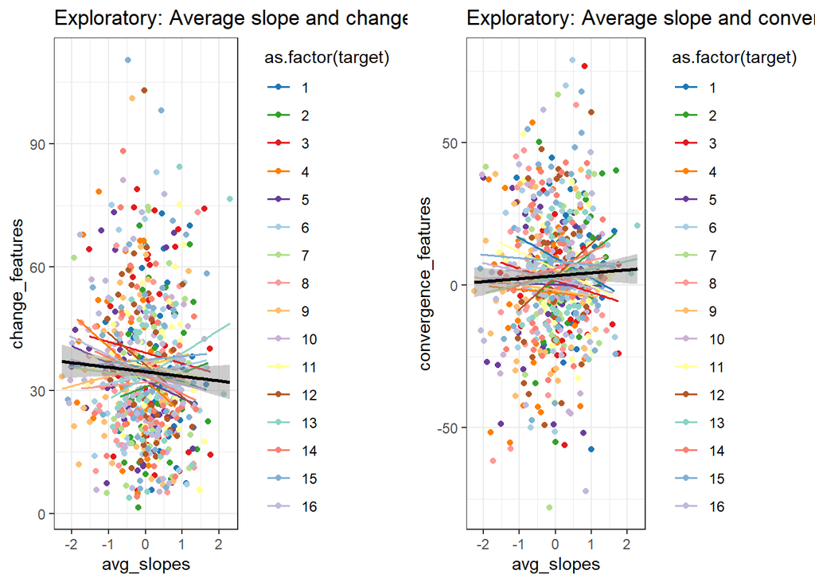

```r
grid.arrange(p1,p2, ncol=2)
```

## plot: intercepts x predist

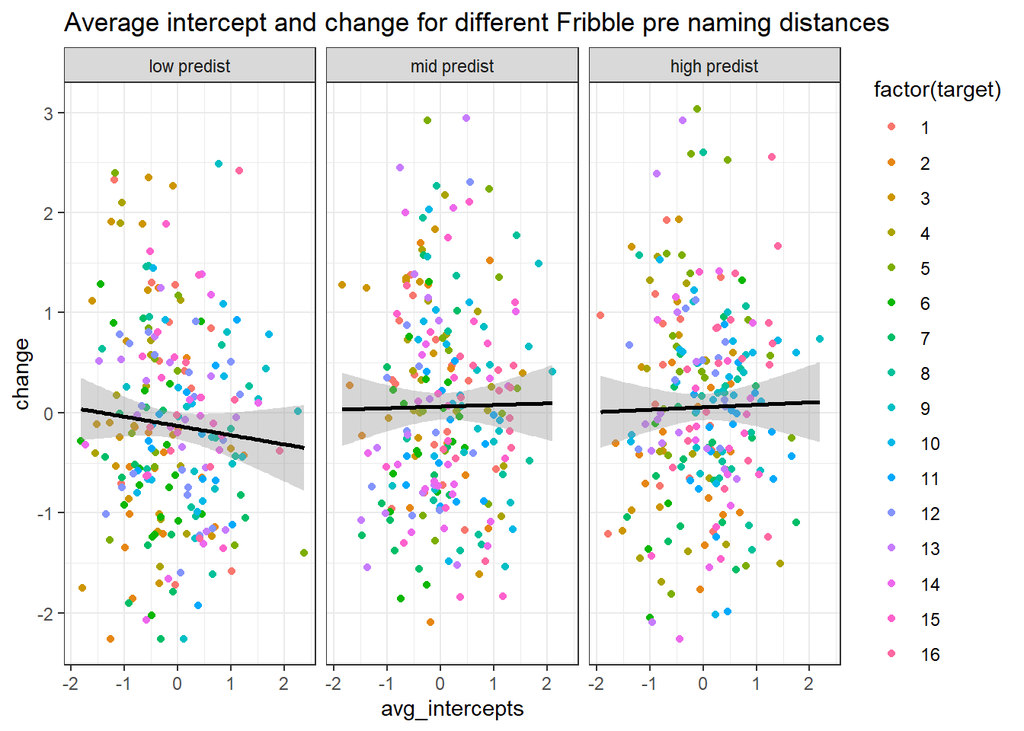

```r
res <- all
res$three <- cut(rank(res$predist),breaks=3,labels = c("low predist","mid predist","high predist"))


p<-ggplot(res, aes(x=avg_intercepts,y=avg_dist)) + geom_point(aes(colour=factor(target), group=pair))+geom_smooth(method='lm', color='black')+ylab("change")+facet_grid(.~three)+ggtitle("Average intercept and change for different Fribble pre naming distances")+theme_bw()

p # facet_grid(three.~) if horizontal
```

```r
# ggsave("./figs/three.png",p,height=7,width=7)
```

# intercepts x predist (Confirmatory hypothesis 3)

```r
#model2 <- lmer(prepost_convergence~avg_intercepts*predist+(1|pair)+(1|target),data=all)
model2 <- lmer(avg_dist~avg_intercepts*predist+(1|pair)+(1|target),data=all)

summary(model2)
```

```
## Linear mixed model fit by REML. t-tests use Satterthwaite's method [
## lmerModLmerTest]
## Formula: avg_dist ~ avg_intercepts * predist + (1 | pair) + (1 | target)
##    Data: all
##
## REML criterion at convergence: 1851.5
##
## Scaled residuals:
##     Min      1Q  Median      3Q     Max
## -2.6814 -0.6984 -0.0052  0.6334  3.4367
##
## Random effects:
##  Groups   Name        Variance Std.Dev.
##  pair     (Intercept) 0.13315  0.3649
##  target   (Intercept) 0.06858  0.2619
##  Residual             0.82099  0.9061
## Number of obs: 672, groups:  pair, 42; target, 16
##
## Fixed effects:
##                        Estimate Std. Error       df t value Pr(>|t|)
## (Intercept)              0.2502     0.3039 261.2568   0.823    0.411
## avg_intercepts          -0.4112     0.3085 658.8913  -1.333    0.183
## predist                 -0.6665     0.7640 303.0420  -0.872    0.384
## avg_intercepts:predist   0.8568     0.7936 662.2172   1.080    0.281
##
## Correlation of Fixed Effects:
##             (Intr) avg_nt predst
## avg_ntrcpts -0.035
## predist     -0.952  0.043
## avg_ntrcpt:  0.041 -0.981 -0.050
```

# Exploratory analyses with the full dataset

# per modality slopes convergence and change

```r
model1 <- lmer(avg_dist~ges_slope+trans_slope+f0_slope+env_slope+(1|pair)+(1|target),data=all)
summary(model1)
```

```
## Linear mixed model fit by REML. t-tests use Satterthwaite's method [
## lmerModLmerTest]
## Formula: avg_dist ~ ges_slope + trans_slope + f0_slope + env_slope + (1 |
##     pair) + (1 | target)
##    Data: all
##
## REML criterion at convergence: 1823.2
##
## Scaled residuals:
##     Min      1Q  Median      3Q     Max
## -2.4814 -0.6877 -0.0091  0.6667  3.2173
##
## Random effects:
##  Groups   Name        Variance Std.Dev.
##  pair     (Intercept) 0.12669  0.3559
##  target   (Intercept) 0.05285  0.2299
##  Residual             0.77152  0.8784
## Number of obs: 672, groups:  pair, 42; target, 16
##
## Fixed effects:
##               Estimate Std. Error         df t value Pr(>|t|)
## (Intercept)  1.071e-16  8.642e-02  3.162e+01   0.000  1.00000
## ges_slope    7.664e-03  5.363e-02  6.542e+02   0.143  0.88642
## trans_slope  1.007e-01  5.007e-02  6.528e+02   2.011  0.04477 *
## f0_slope    -1.187e-01  3.917e-02  6.588e+02  -3.030  0.00254 **
## env_slope   -2.849e-01  6.100e-02  4.445e+02  -4.670 3.99e-06 ***
## ---
## Signif. codes:  0 '***' 0.001 '**' 0.01 '*' 0.05 '.' 0.1 ' ' 1
##
## Correlation of Fixed Effects:
##             (Intr) gs_slp trns_s f0_slp
## ges_slope    0.000
## trans_slope  0.000 -0.216
## f0_slope     0.000 -0.073  0.009
## env_slope    0.000 -0.478 -0.408 -0.155
```

```r
model2 <- lmer(prepost_convergence~ges_slope+trans_slope+f0_slope+env_slope+(1|pair)+(1|target),data=all)
summary(model2)
```

```
## Linear mixed model fit by REML. t-tests use Satterthwaite's method [
## lmerModLmerTest]
## Formula:
## prepost_convergence ~ ges_slope + trans_slope + f0_slope + env_slope +
##     (1 | pair) + (1 | target)
##    Data: all
##
## REML criterion at convergence: 1831.2
##
## Scaled residuals:
##     Min      1Q  Median      3Q     Max
## -3.4672 -0.5790 -0.0287  0.6309  3.2488
##
## Random effects:
##  Groups   Name        Variance Std.Dev.
##  pair     (Intercept) 0.17932  0.4235
##  target   (Intercept) 0.04626  0.2151
##  Residual             0.76994  0.8775
## Number of obs: 672, groups:  pair, 42; target, 16
##
## Fixed effects:
##               Estimate Std. Error         df t value Pr(>|t|)
## (Intercept)  9.985e-17  9.114e-02  3.742e+01   0.000  1.00000
## ges_slope   -5.930e-03  5.413e-02  6.639e+02  -0.110  0.91280
## trans_slope  3.988e-02  5.054e-02  6.623e+02   0.789  0.43033
## f0_slope    -3.396e-02  3.944e-02  6.598e+02  -0.861  0.38952
## env_slope   -1.950e-01  6.258e-02  5.230e+02  -3.117  0.00193 **
## ---
## Signif. codes:  0 '***' 0.001 '**' 0.01 '*' 0.05 '.' 0.1 ' ' 1
##
## Correlation of Fixed Effects:
##             (Intr) gs_slp trns_s f0_slp
## ges_slope    0.000
## trans_slope  0.000 -0.202
## f0_slope     0.000 -0.068  0.016
## env_slope    0.000 -0.486 -0.417 -0.160
```

# per modality intercepts convergence and change

```r
model1 <- lmer(avg_dist~avg_intercepts+(1|pair)+(1|target),data=all)
summary(model1)
```

```
## Linear mixed model fit by REML. t-tests use Satterthwaite's method [
## lmerModLmerTest]
## Formula: avg_dist ~ avg_intercepts + (1 | pair) + (1 | target)
##    Data: all
##
## REML criterion at convergence: 1855.9
##
## Scaled residuals:
##     Min      1Q  Median      3Q     Max
## -2.6228 -0.6856 -0.0084  0.6186  3.4338
##
## Random effects:
##  Groups   Name        Variance Std.Dev.
##  pair     (Intercept) 0.12207  0.3494
##  target   (Intercept) 0.06508  0.2551
##  Residual             0.82475  0.9082
## Number of obs: 672, groups:  pair, 42; target, 16
##
## Fixed effects:
##                  Estimate Std. Error         df t value Pr(>|t|)
## (Intercept)     2.166e-16  9.056e-02  2.873e+01   0.000    1.000
## avg_intercepts -8.337e-02  6.022e-02  4.333e+02  -1.384    0.167
##
## Correlation of Fixed Effects:
##             (Intr)
## avg_ntrcpts 0.000
```

```r
# possible interesting
cor.test(all$avg_intercepts, all$avg_slopes) #note
```

```
##
##  Pearson's product-moment correlation
##
## data:  all$avg_intercepts and all$avg_slopes
## t = 0.3046, df = 670, p-value = 0.7608
## alternative hypothesis: true correlation is not equal to 0
## 95 percent confidence interval:
##  -0.06392167  0.08732127
## sample estimates:
##       cor
## 0.0117671
```

```r
model1 <- lmer(prepost_convergence~avg_intercepts+avg_slopes+(1|pair)+(1|target),data=all)
summary(model1)
```

```
## Linear mixed model fit by REML. t-tests use Satterthwaite's method [
## lmerModLmerTest]
## Formula: prepost_convergence ~ avg_intercepts + avg_slopes + (1 | pair) +
##     (1 | target)
##    Data: all
##
## REML criterion at convergence: 1816.5
##
## Scaled residuals:
##     Min      1Q  Median      3Q     Max
## -3.4609 -0.5918 -0.0288  0.6555  3.1926
##
## Random effects:
##  Groups   Name        Variance Std.Dev.
##  pair     (Intercept) 0.17290  0.4158
##  target   (Intercept) 0.03867  0.1967
##  Residual             0.76483  0.8745
## Number of obs: 672, groups:  pair, 42; target, 16
##
## Fixed effects:
##                  Estimate Std. Error         df t value Pr(>|t|)
## (Intercept)     2.084e-16  8.759e-02  3.849e+01   0.000 1.000000
## avg_intercepts -1.984e-01  5.856e-02  4.060e+02  -3.388 0.000773 ***
## avg_slopes     -1.949e-01  5.267e-02  6.345e+02  -3.700 0.000234 ***
## ---
## Signif. codes:  0 '***' 0.001 '**' 0.01 '*' 0.05 '.' 0.1 ' ' 1
##
## Correlation of Fixed Effects:
##             (Intr) avg_nt
## avg_ntrcpts  0.000
## avg_slopes   0.000 -0.028
```

```r
# possible interesting more different
model1 <- lmer(pre~avg_slopes+avg_intercepts+(1|pair)+(1|target),data=all)
summary(model1)
```

```
## Linear mixed model fit by REML. t-tests use Satterthwaite's method [
## lmerModLmerTest]
## Formula: pre ~ avg_slopes + avg_intercepts + (1 | pair) + (1 | target)
##    Data: all
##
## REML criterion at convergence: 1809.9
##
## Scaled residuals:
##      Min       1Q   Median       3Q      Max
## -2.23767 -0.62104 -0.07745  0.59947  2.92353
##
## Random effects:
##  Groups   Name        Variance Std.Dev.
##  pair     (Intercept) 0.13629  0.3692
##  target   (Intercept) 0.07992  0.2827
##  Residual             0.75595  0.8695
## Number of obs: 672, groups:  pair, 42; target, 16
##
## Fixed effects:
##                  Estimate Std. Error         df t value Pr(>|t|)
## (Intercept)    -2.644e-17  9.677e-02  2.948e+01   0.000    1.000
## avg_slopes     -2.199e-01  5.254e-02  6.471e+02  -4.185 3.25e-05 ***
## avg_intercepts  9.532e-03  5.904e-02  4.868e+02   0.161    0.872
## ---
## Signif. codes:  0 '***' 0.001 '**' 0.01 '*' 0.05 '.' 0.1 ' ' 1
##
## Correlation of Fixed Effects:
##             (Intr) avg_sl
## avg_slopes   0.000
## avg_ntrcpts  0.000 -0.049
```

```r
model1 <- lmer(avg_dist~ges_intercept+trans_intercept+f0_intercept+env_intercept+(1|pair)+(1|target),data=all)
summary(model1)
```

```
## Linear mixed model fit by REML. t-tests use Satterthwaite's method [
## lmerModLmerTest]
## Formula:
## avg_dist ~ ges_intercept + trans_intercept + f0_intercept + env_intercept +
##     (1 | pair) + (1 | target)
##    Data: all
##
## REML criterion at convergence: 1857.3
##
## Scaled residuals:
##     Min      1Q  Median      3Q     Max
## -2.6077 -0.6679 -0.0273  0.6339  3.1902
##
## Random effects:
##  Groups   Name        Variance Std.Dev.
##  pair     (Intercept) 0.11987  0.3462
##  target   (Intercept) 0.06816  0.2611
##  Residual             0.81512  0.9028
## Number of obs: 672, groups:  pair, 42; target, 16
##
## Fixed effects:
##                   Estimate Std. Error         df t value Pr(>|t|)
## (Intercept)      4.221e-16  9.125e-02  2.812e+01   0.000  1.00000
## ges_intercept    2.005e-02  7.203e-02  2.191e+02   0.278  0.78102
## trans_intercept  1.477e-01  6.445e-02  4.268e+02   2.292  0.02239 *
## f0_intercept    -4.979e-03  5.568e-02  1.843e+02  -0.089  0.92885
## env_intercept   -2.207e-01  7.541e-02  2.538e+02  -2.927  0.00374 **
## ---
## Signif. codes:  0 '***' 0.001 '**' 0.01 '*' 0.05 '.' 0.1 ' ' 1
##
## Correlation of Fixed Effects:
##             (Intr) gs_ntr trns_n f0_ntr
## ges_intrcpt  0.000
## trns_ntrcpt  0.000 -0.173
## f0_intercpt  0.000  0.137 -0.256
## env_intrcpt  0.000 -0.615 -0.388 -0.128
```

```r
model2 <- lmer(prepost_convergence~ges_intercept+trans_intercept+f0_intercept+env_intercept+(1|pair)+(1|target),data=all)
summary(model2)
```

```
## Linear mixed model fit by REML. t-tests use Satterthwaite's method [
## lmerModLmerTest]
## Formula:
## prepost_convergence ~ ges_intercept + trans_intercept + f0_intercept +
##     env_intercept + (1 | pair) + (1 | target)
##    Data: all
##
## REML criterion at convergence: 1826.8
##
## Scaled residuals:
##     Min      1Q  Median      3Q     Max
## -3.4708 -0.5679 -0.0506  0.6599  3.0500
##
## Random effects:
##  Groups   Name        Variance Std.Dev.
##  pair     (Intercept) 0.2065   0.4544
##  target   (Intercept) 0.0442   0.2102
##  Residual             0.7619   0.8729
## Number of obs: 672, groups:  pair, 42; target, 16
##
## Fixed effects:
##                   Estimate Std. Error         df t value Pr(>|t|)
## (Intercept)      5.138e-16  9.387e-02  3.914e+01   0.000 1.000000
## ges_intercept    4.141e-02  7.539e-02  3.180e+02   0.549 0.583222
## trans_intercept  5.854e-02  6.507e-02  5.484e+02   0.900 0.368693
## f0_intercept     4.388e-02  5.898e-02  2.647e+02   0.744 0.457488
## env_intercept   -2.773e-01  7.832e-02  3.553e+02  -3.540 0.000453 ***
## ---
## Signif. codes:  0 '***' 0.001 '**' 0.01 '*' 0.05 '.' 0.1 ' ' 1
##
## Correlation of Fixed Effects:
##             (Intr) gs_ntr trns_n f0_ntr
## ges_intrcpt  0.000
## trns_ntrcpt  0.000 -0.141
## f0_intercpt  0.000  0.105 -0.226
## env_intrcpt  0.000 -0.649 -0.404 -0.117
```

# combined model

```r
model1 <- lmer(avg_dist~ges_intercept+trans_intercept+f0_intercept+env_intercept+ges_slope+trans_slope+f0_slope+env_slope+(1|pair)+(1|target),data=all)
summary(model1)
```

```
## Linear mixed model fit by REML. t-tests use Satterthwaite's method [
## lmerModLmerTest]
## Formula:
## avg_dist ~ ges_intercept + trans_intercept + f0_intercept + env_intercept +
##     ges_slope + trans_slope + f0_slope + env_slope + (1 | pair) +
##     (1 | target)
##    Data: all
##
## REML criterion at convergence: 1836.3
##
## Scaled residuals:
##      Min       1Q   Median       3Q      Max
## -2.46857 -0.69046 -0.00465  0.66727  3.13115
##
## Random effects:
##  Groups   Name        Variance Std.Dev.
##  pair     (Intercept) 0.12851  0.3585
##  target   (Intercept) 0.05649  0.2377
##  Residual             0.77236  0.8788
## Number of obs: 672, groups:  pair, 42; target, 16
##
## Fixed effects:
##                   Estimate Std. Error         df t value Pr(>|t|)
## (Intercept)      6.652e-16  8.797e-02  3.089e+01   0.000  1.00000
## ges_intercept   -7.356e-02  7.463e-02  2.566e+02  -0.986  0.32519
## trans_intercept  7.376e-02  6.469e-02  4.325e+02   1.140  0.25481
## f0_intercept    -1.505e-02  5.577e-02  2.032e+02  -0.270  0.78759
## env_intercept   -6.065e-03  8.651e-02  3.583e+02  -0.070  0.94414
## ges_slope        1.363e-02  5.623e-02  6.493e+02   0.242  0.80856
## trans_slope      9.770e-02  5.117e-02  6.478e+02   1.909  0.05669 .
## f0_slope        -1.187e-01  3.951e-02  6.540e+02  -3.003  0.00277 **
## env_slope       -2.816e-01  7.096e-02  5.458e+02  -3.969 8.17e-05 ***
## ---
## Signif. codes:  0 '***' 0.001 '**' 0.01 '*' 0.05 '.' 0.1 ' ' 1
##
## Correlation of Fixed Effects:
##             (Intr) gs_ntr trns_n f0_ntr env_nt gs_slp trns_s f0_slp
## ges_intrcpt  0.000
## trns_ntrcpt  0.000 -0.113
## f0_intercpt  0.000  0.151 -0.227
## env_intrcpt  0.000 -0.660 -0.415 -0.154
## ges_slope    0.000 -0.195  0.010 -0.042  0.258
## trans_slope  0.000 -0.073 -0.057 -0.047  0.180 -0.149
## f0_slope     0.000  0.026  0.009 -0.093 -0.045 -0.088 -0.001
## env_slope    0.000  0.284  0.149  0.112 -0.493 -0.533 -0.443 -0.108
```

# does pre increase invested effort? Lower alignment at pre predicts gesture effort and envelope effort***

```r
model1 <- lmer(pre~ges_intercept+trans_intercept+f0_intercept+env_intercept+(1|pair)+(1|target),data=all)
summary(model1)
```

```
## Linear mixed model fit by REML. t-tests use Satterthwaite's method [
## lmerModLmerTest]
## Formula:
## pre ~ ges_intercept + trans_intercept + f0_intercept + env_intercept +
##     (1 | pair) + (1 | target)
##    Data: all
##
## REML criterion at convergence: 1825.4
##
## Scaled residuals:
##      Min       1Q   Median       3Q      Max
## -2.43951 -0.60937 -0.04946  0.60174  2.87853
##
## Random effects:
##  Groups   Name        Variance Std.Dev.
##  pair     (Intercept) 0.15168  0.3895
##  target   (Intercept) 0.08279  0.2877
##  Residual             0.76336  0.8737
## Number of obs: 672, groups:  pair, 42; target, 16
##
## Fixed effects:
##                   Estimate Std. Error         df t value Pr(>|t|)
## (Intercept)      8.147e-16  9.961e-02  3.046e+01   0.000  1.00000
## ges_intercept    1.998e-01  7.276e-02  2.594e+02   2.746  0.00646 **
## trans_intercept  2.790e-02  6.403e-02  4.854e+02   0.436  0.66325
## f0_intercept     1.557e-02  5.647e-02  2.173e+02   0.276  0.78300
## env_intercept   -2.103e-01  7.591e-02  2.973e+02  -2.770  0.00596 **
## ---
## Signif. codes:  0 '***' 0.001 '**' 0.01 '*' 0.05 '.' 0.1 ' ' 1
##
## Correlation of Fixed Effects:
##             (Intr) gs_ntr trns_n f0_ntr
## ges_intrcpt  0.000
## trns_ntrcpt  0.000 -0.155
## f0_intercpt  0.000  0.122 -0.243
## env_intrcpt  0.000 -0.629 -0.395 -0.122
```

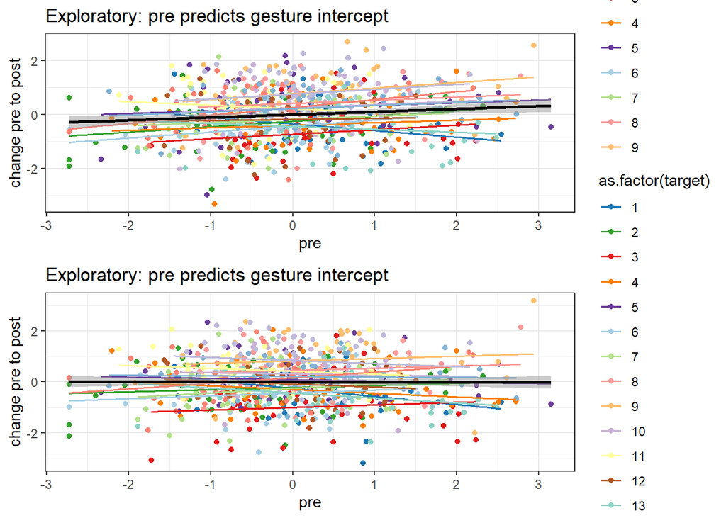

```r
p1 <- ggplot(all,aes(x=pre,y=ges_intercept, color = as.factor(target))) + geom_point(aes(group=pair))+geom_smooth(method='lm', alpha = 0, size = 0.7)+geom_smooth(method='lm', alpha=0.5, color = 'black')+ylab("change pre to post")+ggtitle("Exploratory: pre predicts gesture intercept")+theme_bw()+ scale_color_manual(values = my_custom_palette)

p2 <- ggplot(all,aes(x=pre,y=env_intercept, color = as.factor(target))) + geom_point(aes(group=pair))+geom_smooth(method='lm', alpha = 0, size = 0.7)+geom_smooth(method='lm', alpha=0.5, color = 'black')+ylab("change pre to post")+ggtitle("Exploratory: pre predicts gesture intercept")+theme_bw()+ scale_color_manual(values = my_custom_palette)

grid.arrange(p1,p2)
```

```r
# slopes and change
model1 <- lmer(avg_dist~ges_slope+trans_slope+f0_slope+env_slope+(1|pair)+(1|target),data=all)
summary(model1)
```

```
## Linear mixed model fit by REML. t-tests use Satterthwaite's method [
## lmerModLmerTest]
## Formula: avg_dist ~ ges_slope + trans_slope + f0_slope + env_slope + (1 |
##     pair) + (1 | target)
##    Data: all
##
## REML criterion at convergence: 1823.2
##
## Scaled residuals:
##     Min      1Q  Median      3Q     Max
## -2.4814 -0.6877 -0.0091  0.6667  3.2173
##
## Random effects:
##  Groups   Name        Variance Std.Dev.
##  pair     (Intercept) 0.12669  0.3559
##  target   (Intercept) 0.05285  0.2299
##  Residual             0.77152  0.8784
## Number of obs: 672, groups:  pair, 42; target, 16
##
## Fixed effects:
##               Estimate Std. Error         df t value Pr(>|t|)
## (Intercept)  1.071e-16  8.642e-02  3.162e+01   0.000  1.00000
## ges_slope    7.664e-03  5.363e-02  6.542e+02   0.143  0.88642
## trans_slope  1.007e-01  5.007e-02  6.528e+02   2.011  0.04477 *
## f0_slope    -1.187e-01  3.917e-02  6.588e+02  -3.030  0.00254 **
## env_slope   -2.849e-01  6.100e-02  4.445e+02  -4.670 3.99e-06 ***
## ---
## Signif. codes:  0 '***' 0.001 '**' 0.01 '*' 0.05 '.' 0.1 ' ' 1
##
## Correlation of Fixed Effects:
##             (Intr) gs_slp trns_s f0_slp
## ges_slope    0.000
## trans_slope  0.000 -0.216
## f0_slope     0.000 -0.073  0.009
## env_slope    0.000 -0.478 -0.408 -0.155
```

```r
# slopes and convergence
model1 <- lmer(prepost_convergence~ges_slope+trans_slope+f0_slope+env_slope+(1|pair)+(1|target),data=all)
summary(model1)
```

```
## Linear mixed model fit by REML. t-tests use Satterthwaite's method [
## lmerModLmerTest]
## Formula:
## prepost_convergence ~ ges_slope + trans_slope + f0_slope + env_slope +
##     (1 | pair) + (1 | target)
##    Data: all
##
## REML criterion at convergence: 1831.2
##
## Scaled residuals:
##     Min      1Q  Median      3Q     Max
## -3.4672 -0.5790 -0.0287  0.6309  3.2488
##
## Random effects:
##  Groups   Name        Variance Std.Dev.
##  pair     (Intercept) 0.17932  0.4235
##  target   (Intercept) 0.04626  0.2151
##  Residual             0.76994  0.8775
## Number of obs: 672, groups:  pair, 42; target, 16
##
## Fixed effects:
##               Estimate Std. Error         df t value Pr(>|t|)
## (Intercept)  9.985e-17  9.114e-02  3.742e+01   0.000  1.00000
## ges_slope   -5.930e-03  5.413e-02  6.639e+02  -0.110  0.91280
## trans_slope  3.988e-02  5.054e-02  6.623e+02   0.789  0.43033
## f0_slope    -3.396e-02  3.944e-02  6.598e+02  -0.861  0.38952
## env_slope   -1.950e-01  6.258e-02  5.230e+02  -3.117  0.00193 **
## ---
## Signif. codes:  0 '***' 0.001 '**' 0.01 '*' 0.05 '.' 0.1 ' ' 1
##
## Correlation of Fixed Effects:
##             (Intr) gs_slp trns_s f0_slp
## ges_slope    0.000
## trans_slope  0.000 -0.202
## f0_slope     0.000 -0.068  0.016
## env_slope    0.000 -0.486 -0.417 -0.160
```

```r
# intercepts and change
model1 <- lmer(avg_dist~ges_intercept+trans_slope+f0_intercept+env_intercept+(1|pair)+(1|target),data=all)
summary(model1)
```

```
## Linear mixed model fit by REML. t-tests use Satterthwaite's method [
## lmerModLmerTest]
## Formula:
## avg_dist ~ ges_intercept + trans_slope + f0_intercept + env_intercept +
##     (1 | pair) + (1 | target)
##    Data: all
##
## REML criterion at convergence: 1859.7
##
## Scaled residuals:
##     Min      1Q  Median      3Q     Max
## -2.6676 -0.7009 -0.0195  0.6096  3.3875
##
## Random effects:
##  Groups   Name        Variance Std.Dev.
##  pair     (Intercept) 0.11528  0.3395
##  target   (Intercept) 0.06306  0.2511
##  Residual             0.81953  0.9053
## Number of obs: 672, groups:  pair, 42; target, 16
##
## Fixed effects:
##                 Estimate Std. Error         df t value Pr(>|t|)
## (Intercept)    2.666e-16  8.891e-02  2.797e+01   0.000   1.0000
## ges_intercept  4.110e-02  7.076e-02  1.901e+02   0.581   0.5620
## trans_slope   -7.824e-02  3.977e-02  6.527e+02  -1.968   0.0495 *
## f0_intercept   2.603e-02  5.357e-02  1.556e+02   0.486   0.6277
## env_intercept -1.459e-01  6.938e-02  2.826e+02  -2.103   0.0363 *
## ---
## Signif. codes:  0 '***' 0.001 '**' 0.01 '*' 0.05 '.' 0.1 ' ' 1
##
## Correlation of Fixed Effects:
##             (Intr) gs_ntr trns_s f0_ntr
## ges_intrcpt  0.000
## trans_slope  0.000  0.062
## f0_intercpt  0.000  0.100  0.022
## env_intrcpt  0.000 -0.751 -0.054 -0.257
```

```r
# intercepts and convergence
model1 <- lmer(prepost_convergence~ges_intercept+trans_intercept+f0_intercept+env_intercept+(1|pair)+(1|target),data=all)
summary(model1)
```

```
## Linear mixed model fit by REML. t-tests use Satterthwaite's method [
## lmerModLmerTest]
## Formula:
## prepost_convergence ~ ges_intercept + trans_intercept + f0_intercept +
##     env_intercept + (1 | pair) + (1 | target)
##    Data: all
##
## REML criterion at convergence: 1826.8
##
## Scaled residuals:
##     Min      1Q  Median      3Q     Max
## -3.4708 -0.5679 -0.0506  0.6599  3.0500
##
## Random effects:
##  Groups   Name        Variance Std.Dev.
##  pair     (Intercept) 0.2065   0.4544
##  target   (Intercept) 0.0442   0.2102
##  Residual             0.7619   0.8729
## Number of obs: 672, groups:  pair, 42; target, 16
##
## Fixed effects:
##                   Estimate Std. Error         df t value Pr(>|t|)
## (Intercept)      5.138e-16  9.387e-02  3.914e+01   0.000 1.000000
## ges_intercept    4.141e-02  7.539e-02  3.180e+02   0.549 0.583222
## trans_intercept  5.854e-02  6.507e-02  5.484e+02   0.900 0.368693
## f0_intercept     4.388e-02  5.898e-02  2.647e+02   0.744 0.457488
## env_intercept   -2.773e-01  7.832e-02  3.553e+02  -3.540 0.000453 ***
## ---
## Signif. codes:  0 '***' 0.001 '**' 0.01 '*' 0.05 '.' 0.1 ' ' 1
##
## Correlation of Fixed Effects:
##             (Intr) gs_ntr trns_n f0_ntr
## ges_intrcpt  0.000
## trns_ntrcpt  0.000 -0.141
## f0_intercpt  0.000  0.105 -0.226
## env_intrcpt  0.000 -0.649 -0.404 -0.117
```

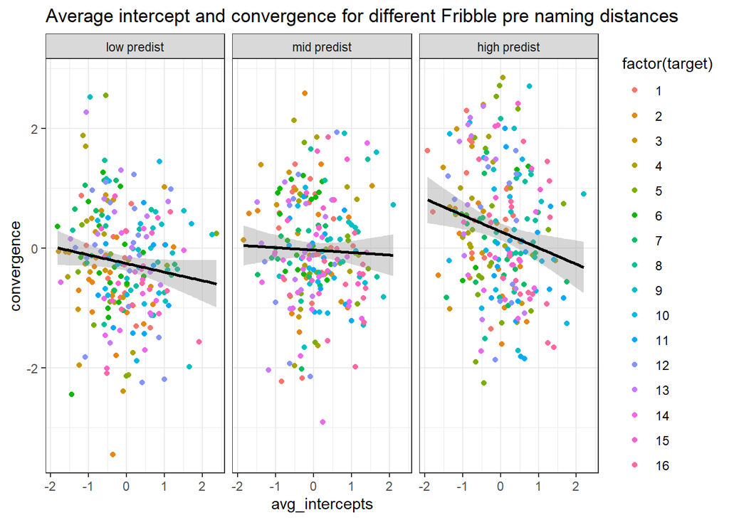

```r
res <- all
res$three <- cut(rank(res$predist),breaks=3,labels = c("low predist","mid predist","high predist"))


p<-ggplot(res, aes(x=avg_intercepts,y=prepost_convergence)) + geom_point(aes(colour=factor(target), group=pair))+geom_smooth(method='lm', color='black')+ylab("convergence")+facet_grid(.~three)+ggtitle("Average intercept and convergence for different Fribble pre naming distances")+theme_bw()

#p<-ggplot(res, aes(x=avg_slopes,y=predist)) + geom_point(aes(colour=factor(target), group=pair))+geom_smooth(method='lm', color='black')+ylab("predist")

p # facet_grid(three.~) if horizontal
```

```r
model2 <- lmer(prepost_convergence~avg_intercepts*predist+(1|pair)+(1|target),data=all)

summary(model2)
```

```
## Linear mixed model fit by REML. t-tests use Satterthwaite's method [
## lmerModLmerTest]
## Formula: prepost_convergence ~ avg_intercepts * predist + (1 | pair) +
##     (1 | target)
##    Data: all
##
## REML criterion at convergence: 1811.4
##
## Scaled residuals:
##     Min      1Q  Median      3Q     Max
## -3.3692 -0.5909 -0.0341  0.6420  3.1336
##
## Random effects:
##  Groups   Name        Variance Std.Dev.
##  pair     (Intercept) 0.12328  0.3511
##  target   (Intercept) 0.04341  0.2083
##  Residual             0.77921  0.8827
## Number of obs: 672, groups:  pair, 42; target, 16
##
## Fixed effects:
##                        Estimate Std. Error       df t value Pr(>|t|)
## (Intercept)             -0.9145     0.2924 258.1113  -3.128  0.00196 **
## avg_intercepts           0.3567     0.2995 659.4334   1.191  0.23411
## predist                  2.4248     0.7408 295.1862   3.273  0.00119 **
## avg_intercepts:predist  -1.4670     0.7713 663.9953  -1.902  0.05761 .
## ---
## Signif. codes:  0 '***' 0.001 '**' 0.01 '*' 0.05 '.' 0.1 ' ' 1
##
## Correlation of Fixed Effects:
##             (Intr) avg_nt predst
## avg_ntrcpts -0.033
## predist     -0.959  0.042
## avg_ntrcpt:  0.040 -0.981 -0.049
```

# Empirical proof of analytical reasoning in the discussion

Note that a constant proportional reduction rate yields a curvilinear reduction, but it is logarithmic reduction and not a power function.

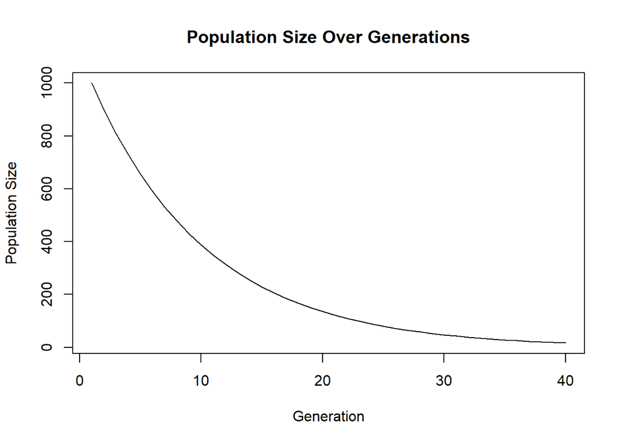

```r
# does more effort in the beginning, predict lower effort at end
# Define parameters
initial_population <- 1000
max_generations <- 40
selection_constant <- 0.1 #Adjust as needed

# Function to calculate selection rate based on population size
calculate_selection_rate <- function(population_size) {
  return(selection_constant*(population_size))
}

# Function to simulate evolution and return population sizes over generations
simulate_evolution <- function(initial_population, max_generations) {
  population_sizes <- numeric(max_generations)
  population <- initial_population

  for (generation in 1:max_generations) {
    # Store current population size
    population_sizes[generation] <- population

    # Calculate selection rate based on current population size
    selection_rate <- calculate_selection_rate(population)

    # Reduce population size based on selection rate
    population <- population - selection_rate

    # Break the loop if population becomes zero
    if (population <= 0) {
      cat("Population extinct at generation", generation, "\n")
      break
    }
  }

  return(population_sizes)
}

# Run the simulation
population_sizes <- simulate_evolution(initial_population, max_generations)

# Plot population size over generations
plot(1:max_generations, population_sizes, type = "l", xlab = "Generation", ylab = "Population Size", main = "Population Size Over Generations")
```

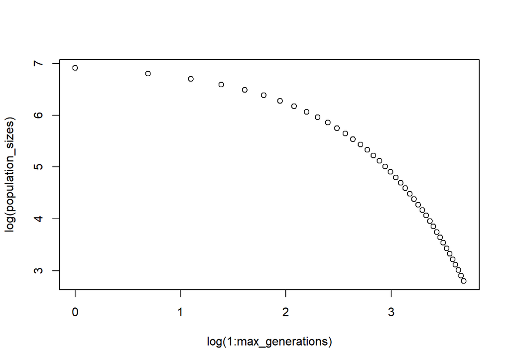

```r
plot(log(1:max_generations), log(population_sizes)) #logarithmic relation
```